# HNSCC UNM Althoff et al_Clinical Analysis

George Laliotis, MD

2026-07-18

# 0. Purpose of the document and initial set-up

- **Scripts** — Provide the scripts used for the clinical analysis regarding the clinical utility of MRD in HNSCC patients in Althoff et al (2026).
- **Clinical Analysis output** — Provide the raw outputs of the clinical analysis and figures used in the manuscript.

```r
# **Loading necessary Documents**

library(swimplot)
library(grid)
library(gtable)
library(readr)
library(mosaic)
library(forcats)
library(dplyr)
library(survival)
library(survminer)
library(ggplot2)
library(scales)
library(coxphf)
library(ggthemes)
library(tidyverse)
library(gtsummary)
library(flextable)
library(reshape2)
library(parameters)
library(car)
library(ComplexHeatmap)
library(tidyverse)
library(readxl)
library(janitor)
library(DT)
library(pROC)
library(rms)
```

# 1. Figure 1

- **Flow chart** — Flow chart depicting ctDNA results by stage at baseline and in the MRD and post-definitive treatment surveillance windows
- **Demographics Tables** — Tables with Patient and tumor characteristics (Table 1 & Supplementary Table 1)

```r
# **ctDNA Detection Rates by Window and Stages**
# **ctDNA at Baseline**
rm(list=ls())
setwd("~/Downloads")
circ_data <- read.csv("CLIA HNSCC Peddada Clinical Data.csv")
circ_data <- circ_data[circ_data$ctDNA.available=="TRUE",]
circ_data <- circ_data[circ_data$ctDNA.Base!="",]
circ_data$ctDNA.Base <- factor(circ_data$ctDNA.Base, levels=c("NEGATIVE","POSITIVE"))
circ_data <- subset(circ_data, ctDNA.Base %in% c("NEGATIVE", "POSITIVE"))
circ_data$Stage <- factor(circ_data$Stage, levels=c("I/II","III/IVA/IVB","IVC"))
positive_counts_by_stage <- aggregate(circ_data$ctDNA.Base == "POSITIVE", by=list(circ_data$Stage), FUN=sum)
total_counts_by_stage <- aggregate(circ_data$ctDNA.Base, by=list(circ_data$Stage), FUN=length)
combined_data <- data.frame(
  Stage = total_counts_by_stage$Group.1,
  Total_Count = total_counts_by_stage$x,
  Positive_Count = positive_counts_by_stage$x,
  Rate = (positive_counts_by_stage$x / total_counts_by_stage$x) * 100  # Convert to percentage
)
combined_data$Rate <- sprintf("%.2f%%", combined_data$Rate)
overall_total_count <- nrow(circ_data)
overall_positive_count <- nrow(circ_data[circ_data$ctDNA.Base == "POSITIVE",])
overall_positivity_rate <- (overall_positive_count / overall_total_count) * 100  # Convert to percentage
overall_row <- data.frame(
  Stage = "Overall",
  Total_Count = overall_total_count,
  Positive_Count = overall_positive_count,
  Rate = sprintf("%.2f%%", overall_positivity_rate)
)
combined_data <- rbind(combined_data, overall_row)
print(combined_data)
```

```
##         Stage Total_Count Positive_Count    Rate
## 1        I/II          34             32  94.12%
## 2 III/IVA/IVB          27             22  81.48%
## 3         IVC           2              2 100.00%
## 4     Overall          63             56  88.89%
```

```r
# **ctDNA at MRD**
rm(list=ls())
setwd("~/Downloads")
circ_data <- read.csv("CLIA HNSCC Peddada Clinical Data.csv")
circ_data <- circ_data[circ_data$ctDNA.available=="TRUE",]
circ_data <- circ_data[circ_data$ctDNA.MRD!="",]
circ_data$ctDNA.MRD <- factor(circ_data$ctDNA.MRD, levels=c("NEGATIVE","POSITIVE"))
circ_data$Stage <- factor(circ_data$Stage, levels=c("I/II","III/IVA/IVB","IVC"))
positive_counts_by_stage <- aggregate(circ_data$ctDNA.MRD == "POSITIVE", by=list(circ_data$Stage), FUN=sum)
total_counts_by_stage <- aggregate(circ_data$ctDNA.MRD, by=list(circ_data$Stage), FUN=length)
combined_data <- data.frame(
  Stage = total_counts_by_stage$Group.1,
  Total_Count = total_counts_by_stage$x,
  Positive_Count = positive_counts_by_stage$x,
  Rate = (positive_counts_by_stage$x / total_counts_by_stage$x) * 100  # Convert to percentage
)
combined_data$Rate <- sprintf("%.2f%%", combined_data$Rate)
overall_total_count <- nrow(circ_data)
overall_positive_count <- nrow(circ_data[circ_data$ctDNA.MRD == "POSITIVE",])
overall_positivity_rate <- (overall_positive_count / overall_total_count) * 100  # Convert to percentage
overall_row <- data.frame(
  Stage = "Overall",
  Total_Count = overall_total_count,
  Positive_Count = overall_positive_count,
  Rate = sprintf("%.2f%%", overall_positivity_rate)
)
combined_data <- rbind(combined_data, overall_row)
print(combined_data)
```

```
##         Stage Total_Count Positive_Count   Rate
## 1        I/II          34              5 14.71%
## 2 III/IVA/IVB          33              7 21.21%
## 3         IVC           2              1 50.00%
## 4     Overall          69             13 18.84%
```

```r
# **ctDNA at Surveillance**
rm(list=ls())
setwd("~/Downloads")
circ_data <- read.csv("CLIA HNSCC Peddada Clinical Data.csv")
circ_data <- circ_data[circ_data$ctDNA.available=="TRUE",]
circ_data <- circ_data[circ_data$ctDNA.Surveillance!="",]
circ_data$ctDNA.Surveillance <- factor(circ_data$ctDNA.Surveillance, levels=c("NEGATIVE","POSITIVE"))
circ_data$Stage <- factor(circ_data$Stage, levels=c("I/II","III/IVA/IVB","IVC"))
positive_counts_by_stage <- aggregate(circ_data$ctDNA.Surveillance == "POSITIVE", by=list(circ_data$Stage), FUN=sum)
total_counts_by_stage <- aggregate(circ_data$ctDNA.Surveillance, by=list(circ_data$Stage), FUN=length)
combined_data <- data.frame(
  Stage = total_counts_by_stage$Group.1,
  Total_Count = total_counts_by_stage$x,
  Positive_Count = positive_counts_by_stage$x,
  Rate = (positive_counts_by_stage$x / total_counts_by_stage$x) * 100  # Convert to percentage
)
combined_data$Rate <- sprintf("%.2f%%", combined_data$Rate)
overall_total_count <- nrow(circ_data)
overall_positive_count <- nrow(circ_data[circ_data$ctDNA.Surveillance == "POSITIVE",])
overall_positivity_rate <- (overall_positive_count / overall_total_count) * 100  # Convert to percentage
overall_row <- data.frame(
  Stage = "Overall",
  Total_Count = overall_total_count,
  Positive_Count = overall_positive_count,
  Rate = sprintf("%.2f%%", overall_positivity_rate)
)
combined_data <- rbind(combined_data, overall_row)
print(combined_data)
```

```
##         Stage Total_Count Positive_Count   Rate
## 1        I/II          42             10 23.81%
## 2 III/IVA/IVB          35             13 37.14%
## 3         IVC           2              1 50.00%
## 4     Overall          79             24 30.38%
```

```r
# **Demographics Table**

rm(list=ls())
setwd("~/Downloads")
circ_data <- read.csv("CLIA HNSCC Peddada Clinical Data.csv")
circ_data <- circ_data[circ_data$ctDNA.available=="TRUE",]

circ_data_subset <- circ_data %>%
  select(
    Sex,
    Age,
    Tobacco.History,
    Prim.Location,
    cT,
    cN,
    cM,
    Histology,
    Stage,
    p16.status,
    Treatment.Group,
    PFS.Event,
    OS.Event,
    OS.months) %>%
  mutate(
    Sex = factor(Sex),
    Age = as.numeric(Age),
    Tobacco.History = factor(Tobacco.History),
    Prim.Location = factor(Prim.Location),
    cT = factor(cT),
    cN = factor(cN),
    cM = factor(cM),
    Histology = factor(Histology),
    Stage = factor(Stage),
    p16.status = factor(p16.status),
    Treatment.Group = factor(Treatment.Group),
    PFS.Event = factor(PFS.Event, levels = c("FALSE", "TRUE"), labels = c("No Progression", "Progression")),
    OS.Event = factor(OS.Event, levels = c("FALSE", "TRUE"), labels = c("Alive", "Deceased")),
    OS.months = as.numeric(OS.months))
table1 <- circ_data_subset %>%
  tbl_summary(
    statistic = list(
      all_continuous() ~ "{median} ({min} - {max})",
      all_categorical() ~ "{n} ({p}%)")) %>%
  bold_labels()
table1
```

| **Characteristic** | **N = 97**<sup>1</sup> |
| --- | --- |
| Sex |  |
| Female | 17 (18%) |
| Male | 80 (82%) |
| Age | 67 (30 - 96) |
| Tobacco.History | 63 (65%) |
| Prim.Location |  |
| Larynx/Hypopharynx | 5 (5.2%) |
| Oral cavity | 16 (16%) |
| Oropharynx | 67 (69%) |
| Other (paranasal sinus and nasopharyngeal) | 9 (9.3%) |
| cT |  |
| T0 | 2 (2.1%) |
| T1 | 12 (12%) |
| T2 | 31 (32%) |
| T3 | 30 (31%) |
| T4 | 21 (22%) |
| TX | 1 (1.0%) |
| cN |  |
| N0 | 22 (23%) |
| N1 | 33 (34%) |
| N2 | 33 (34%) |
| N3 | 9 (9.3%) |
| cM |  |
| M0 | 93 (96%) |
| M1 | 4 (4.1%) |
| Histology |  |
| Adenosquamous carcinoma | 1 (1.0%) |
| Basaloid squamous cell carcinoma | 6 (6.2%) |
| Epithelial myoepithelial carcinoma | 1 (1.0%) |
| Squamous cell carcinoma | 86 (89%) |
| Undifferentiated carcinoma | 3 (3.1%) |
| Stage |  |
| I/II | 49 (51%) |
| III/IVA/IVB | 45 (46%) |
| IVC | 3 (3.1%) |
| p16.status |  |
| Negative | 43 (44%) |
| Positive | 54 (56%) |
| Treatment.Group |  |
| Definitive CRT or RT | 69 (71%) |
| None (Declined Treatment) | 1 (1.0%) |
| None (Hospice) | 2 (2.1%) |
| Surgery + CRT or RT | 24 (25%) |
| Surgery only | 1 (1.0%) |
| PFS.Event |  |
| No Progression | 63 (65%) |
| Progression | 34 (35%) |
| OS.Event |  |
| Alive | 81 (84%) |
| Deceased | 16 (16%) |
| OS.months | 22 (2 - 56) |

<sup>1</sup> n (%); Median (Min - Max)

```r
fit1 <- as_flex_table(
  table1,
  include = everything(),
  return_calls = FALSE
)
fit1
```

| Characteristic | N = 971 |
| --- | --- |
| Sex |  |
| Female | 17 (18%) |
| Male | 80 (82%) |
| Age | 67 (30 - 96) |
| Tobacco.History | 63 (65%) |
| Prim.Location |  |
| Larynx/Hypopharynx | 5 (5.2%) |
| Oral cavity | 16 (16%) |
| Oropharynx | 67 (69%) |
| Other (paranasal sinus and nasopharyngeal) | 9 (9.3%) |
| cT |  |
| T0 | 2 (2.1%) |
| T1 | 12 (12%) |
| T2 | 31 (32%) |
| T3 | 30 (31%) |
| T4 | 21 (22%) |
| TX | 1 (1.0%) |
| cN |  |
| N0 | 22 (23%) |
| N1 | 33 (34%) |
| N2 | 33 (34%) |
| N3 | 9 (9.3%) |
| cM |  |
| M0 | 93 (96%) |
| M1 | 4 (4.1%) |
| Histology |  |
| Adenosquamous carcinoma | 1 (1.0%) |
| Basaloid squamous cell carcinoma | 6 (6.2%) |
| Epithelial myoepithelial carcinoma | 1 (1.0%) |
| Squamous cell carcinoma | 86 (89%) |
| Undifferentiated carcinoma | 3 (3.1%) |
| Stage |  |
| I/II | 49 (51%) |
| III/IVA/IVB | 45 (46%) |
| IVC | 3 (3.1%) |
| p16.status |  |
| Negative | 43 (44%) |
| Positive | 54 (56%) |
| Treatment.Group |  |
| Definitive CRT or RT | 69 (71%) |
| None (Declined Treatment) | 1 (1.0%) |
| None (Hospice) | 2 (2.1%) |
| Surgery + CRT or RT | 24 (25%) |
| Surgery only | 1 (1.0%) |
| PFS.Event |  |
| No Progression | 63 (65%) |
| Progression | 34 (35%) |
| OS.Event |  |
| Alive | 81 (84%) |
| Deceased | 16 (16%) |
| OS.months | 22 (2 - 56) |

1n (%); Median (Min - Max)

```r
save_as_docx(fit1, path= "~/Downloads/1. CLIA HNSCC UNM Demographics Table.docx")
```

```r
# **Demographics Table by ctDNA at baseline**

rm(list=ls())
setwd("~/Downloads")
circ_data <- read.csv("CLIA HNSCC Peddada Clinical Data.csv")
circ_data <- circ_data[circ_data$ctDNA.available=="TRUE",]

circ_data_subset1 <- circ_data %>%
  select(
    Sex,
    Age,
    Tobacco.History,
    Prim.Location,
    cT,
    cN,
    cM,
    Histology,
    Stage,
    p16.status,
    Treatment.Group,
    PFS.Event,
    OS.Event,
    OS.months) %>%
  mutate(
    Sex = factor(Sex),
    Age = as.numeric(Age),
    Tobacco.History = factor(Tobacco.History),
    Prim.Location = factor(Prim.Location),
    cT = factor(cT),
    cN = factor(cN),
    cM = factor(cM),
    Histology = factor(Histology),
    Stage = factor(Stage),
    p16.status = factor(p16.status),
    Treatment.Group = factor(Treatment.Group),
    PFS.Event = factor(PFS.Event, levels = c("FALSE", "TRUE"), labels = c("No Progression", "Progression")),
    OS.Event = factor(OS.Event, levels = c("FALSE", "TRUE"), labels = c("Alive", "Deceased")),
    OS.months = as.numeric(OS.months))

circ_data1 <- read.csv("CLIA HNSCC Peddada Clinical Data.csv")
circ_data <- circ_data[circ_data$ctDNA.available=="TRUE",]

circ_data_subset2 <- circ_data1 %>%
  select(
    Sex,
    Age,
    Tobacco.History,
    Prim.Location,
    cT,
    cN,
    cM,
    Histology,
    Stage,
    p16.status,
    Treatment.Group,
    PFS.Event,
    OS.Event,
    OS.months,
    ctDNA.Base) %>%
  mutate(
    Sex = factor(Sex),
    Age = as.numeric(Age),
    Tobacco.History = factor(Tobacco.History),
    Prim.Location = factor(Prim.Location),
    cT = factor(cT),
    cN = factor(cN),
    cM = factor(cM),
    Histology = factor(Histology),
    Stage = factor(Stage),
    p16.status = factor(p16.status),
    Treatment.Group = factor(Treatment.Group),
    PFS.Event = factor(PFS.Event, levels = c("FALSE", "TRUE"), labels = c("No Progression", "Progression")),
    OS.Event = factor(OS.Event, levels = c("FALSE", "TRUE"), labels = c("Alive", "Deceased")),
    OS.months = as.numeric(OS.months),
    ctDNA.Base = factor(ctDNA.Base, levels = c("NEGATIVE", "POSITIVE"), labels = c("Negative", "Positive")))
Overall <- circ_data_subset1 %>%
  tbl_summary(
    statistic = list(
      all_continuous() ~ "{median} ({min} - {max})",
      all_categorical() ~ "{n} ({p}%)")) %>%
  bold_labels()
Overall
```

| **Characteristic** | **N = 97**<sup>1</sup> |
| --- | --- |
| Sex |  |
| Female | 17 (18%) |
| Male | 80 (82%) |
| Age | 67 (30 - 96) |
| Tobacco.History | 63 (65%) |
| Prim.Location |  |
| Larynx/Hypopharynx | 5 (5.2%) |
| Oral cavity | 16 (16%) |
| Oropharynx | 67 (69%) |
| Other (paranasal sinus and nasopharyngeal) | 9 (9.3%) |
| cT |  |
| T0 | 2 (2.1%) |
| T1 | 12 (12%) |
| T2 | 31 (32%) |
| T3 | 30 (31%) |
| T4 | 21 (22%) |
| TX | 1 (1.0%) |
| cN |  |
| N0 | 22 (23%) |
| N1 | 33 (34%) |
| N2 | 33 (34%) |
| N3 | 9 (9.3%) |
| cM |  |
| M0 | 93 (96%) |
| M1 | 4 (4.1%) |
| Histology |  |
| Adenosquamous carcinoma | 1 (1.0%) |
| Basaloid squamous cell carcinoma | 6 (6.2%) |
| Epithelial myoepithelial carcinoma | 1 (1.0%) |
| Squamous cell carcinoma | 86 (89%) |
| Undifferentiated carcinoma | 3 (3.1%) |
| Stage |  |
| I/II | 49 (51%) |
| III/IVA/IVB | 45 (46%) |
| IVC | 3 (3.1%) |
| p16.status |  |
| Negative | 43 (44%) |
| Positive | 54 (56%) |
| Treatment.Group |  |
| Definitive CRT or RT | 69 (71%) |
| None (Declined Treatment) | 1 (1.0%) |
| None (Hospice) | 2 (2.1%) |
| Surgery + CRT or RT | 24 (25%) |
| Surgery only | 1 (1.0%) |
| PFS.Event |  |
| No Progression | 63 (65%) |
| Progression | 34 (35%) |
| OS.Event |  |
| Alive | 81 (84%) |
| Deceased | 16 (16%) |
| OS.months | 22 (2 - 56) |

<sup>1</sup> n (%); Median (Min - Max)

```r
ByctDNA_MRD <- circ_data_subset2 %>%
  tbl_summary(
    by = ctDNA.Base, # add this line to subgroup by ctDNA.Base
    statistic = list(
      all_continuous() ~ "{median} ({min} - {max})",
      all_categorical() ~ "{n} ({p}%)")) %>%
  add_p() %>%
  bold_labels()
ByctDNA_MRD
```

| **Characteristic** | **Negative** N = 7<sup>1</sup> | **Positive** N = 56<sup>1</sup> | **p-value**<sup>2</sup> |
| --- | --- | --- | --- |
| Sex |  |  | 0.10 |
| Female | 3 (43%) | 8 (14%) |  |
| Male | 4 (57%) | 48 (86%) |  |
| Age | 81 (54 - 96) | 66 (38 - 96) | 0.080 |
| Tobacco.History | 4 (57%) | 38 (68%) | 0.7 |
| Prim.Location |  |  | 0.066 |
| Larynx/Hypopharynx | 0 (0%) | 3 (5.4%) |  |
| Oral cavity | 3 (43%) | 5 (8.9%) |  |
| Oropharynx | 3 (43%) | 44 (79%) |  |
| Other (paranasal sinus and nasopharyngeal) | 1 (14%) | 4 (7.1%) |  |
| cT |  |  | 0.051 |
| T0 | 0 (0%) | 2 (3.6%) |  |
| T1 | 1 (14%) | 4 (7.1%) |  |
| T2 | 2 (29%) | 20 (36%) |  |
| T3 | 0 (0%) | 21 (38%) |  |
| T4 | 4 (57%) | 9 (16%) |  |
| TX | 0 (0%) | 0 (0%) |  |
| cN |  |  | >0.9 |
| N0 | 1 (14%) | 11 (20%) |  |
| N1 | 3 (43%) | 19 (34%) |  |
| N2 | 3 (43%) | 20 (36%) |  |
| N3 | 0 (0%) | 6 (11%) |  |
| cM |  |  | >0.9 |
| M0 | 7 (100%) | 54 (96%) |  |
| M1 | 0 (0%) | 2 (3.6%) |  |
| Histology |  |  | 0.14 |
| Adenosquamous carcinoma | 0 (0%) | 0 (0%) |  |
| Basaloid squamous cell carcinoma | 0 (0%) | 3 (5.4%) |  |
| Epithelial myoepithelial carcinoma | 0 (0%) | 0 (0%) |  |
| Squamous cell carcinoma | 6 (86%) | 53 (95%) |  |
| Undifferentiated carcinoma | 1 (14%) | 0 (0%) |  |
| Stage |  |  | 0.4 |
| I/II | 2 (29%) | 32 (57%) |  |
| III/IVA/IVB | 5 (71%) | 22 (39%) |  |
| IVC | 0 (0%) | 2 (3.6%) |  |
| p16.status |  |  | 0.095 |
| Negative | 5 (71%) | 19 (34%) |  |
| Positive | 2 (29%) | 37 (66%) |  |
| Treatment.Group |  |  | 0.3 |
| Definitive CRT or RT | 5 (71%) | 51 (91%) |  |
| None (Declined Treatment) | 0 (0%) | 0 (0%) |  |
| None (Hospice) | 0 (0%) | 1 (1.8%) |  |
| Surgery + CRT or RT | 2 (29%) | 3 (5.4%) |  |
| Surgery only | 0 (0%) | 1 (1.8%) |  |
| PFS.Event |  |  | 0.4 |
| No Progression | 6 (86%) | 35 (63%) |  |
| Progression | 1 (14%) | 21 (38%) |  |
| OS.Event |  |  | 0.3 |
| Alive | 7 (100%) | 44 (79%) |  |
| Deceased | 0 (0%) | 12 (21%) |  |
| OS.months | 31 (21 - 39) | 16 (2 - 45) | 0.026 |

<sup>1</sup> n (%); Median (Min - Max)  
<sup>2</sup> Fisher’s exact test; Wilcoxon rank sum test

```r
merged_table <- tbl_merge(tbls=list(Overall, ByctDNA_MRD))
merged_table
```

| **Characteristic** | **Table 1** **N = 97**<sup>1</sup> | **Table 2** **Negative** N = 7<sup>1</sup> | **Table 2** **Positive** N = 56<sup>1</sup> | **Table 2** **p-value**<sup>2</sup> |
| --- | --- | --- | --- | --- |
| Sex |  |  |  | 0.10 |
| Female | 17 (18%) | 3 (43%) | 8 (14%) |  |
| Male | 80 (82%) | 4 (57%) | 48 (86%) |  |
| Age | 67 (30 - 96) | 81 (54 - 96) | 66 (38 - 96) | 0.080 |
| Tobacco.History | 63 (65%) | 4 (57%) | 38 (68%) | 0.7 |
| Prim.Location |  |  |  | 0.066 |
| Larynx/Hypopharynx | 5 (5.2%) | 0 (0%) | 3 (5.4%) |  |
| Oral cavity | 16 (16%) | 3 (43%) | 5 (8.9%) |  |
| Oropharynx | 67 (69%) | 3 (43%) | 44 (79%) |  |
| Other (paranasal sinus and nasopharyngeal) | 9 (9.3%) | 1 (14%) | 4 (7.1%) |  |
| cT |  |  |  | 0.051 |
| T0 | 2 (2.1%) | 0 (0%) | 2 (3.6%) |  |
| T1 | 12 (12%) | 1 (14%) | 4 (7.1%) |  |
| T2 | 31 (32%) | 2 (29%) | 20 (36%) |  |
| T3 | 30 (31%) | 0 (0%) | 21 (38%) |  |
| T4 | 21 (22%) | 4 (57%) | 9 (16%) |  |
| TX | 1 (1.0%) | 0 (0%) | 0 (0%) |  |
| cN |  |  |  | >0.9 |
| N0 | 22 (23%) | 1 (14%) | 11 (20%) |  |
| N1 | 33 (34%) | 3 (43%) | 19 (34%) |  |
| N2 | 33 (34%) | 3 (43%) | 20 (36%) |  |
| N3 | 9 (9.3%) | 0 (0%) | 6 (11%) |  |
| cM |  |  |  | >0.9 |
| M0 | 93 (96%) | 7 (100%) | 54 (96%) |  |
| M1 | 4 (4.1%) | 0 (0%) | 2 (3.6%) |  |
| Histology |  |  |  | 0.14 |
| Adenosquamous carcinoma | 1 (1.0%) | 0 (0%) | 0 (0%) |  |
| Basaloid squamous cell carcinoma | 6 (6.2%) | 0 (0%) | 3 (5.4%) |  |
| Epithelial myoepithelial carcinoma | 1 (1.0%) | 0 (0%) | 0 (0%) |  |
| Squamous cell carcinoma | 86 (89%) | 6 (86%) | 53 (95%) |  |
| Undifferentiated carcinoma | 3 (3.1%) | 1 (14%) | 0 (0%) |  |
| Stage |  |  |  | 0.4 |
| I/II | 49 (51%) | 2 (29%) | 32 (57%) |  |
| III/IVA/IVB | 45 (46%) | 5 (71%) | 22 (39%) |  |
| IVC | 3 (3.1%) | 0 (0%) | 2 (3.6%) |  |
| p16.status |  |  |  | 0.095 |
| Negative | 43 (44%) | 5 (71%) | 19 (34%) |  |
| Positive | 54 (56%) | 2 (29%) | 37 (66%) |  |
| Treatment.Group |  |  |  | 0.3 |
| Definitive CRT or RT | 69 (71%) | 5 (71%) | 51 (91%) |  |
| None (Declined Treatment) | 1 (1.0%) | 0 (0%) | 0 (0%) |  |
| None (Hospice) | 2 (2.1%) | 0 (0%) | 1 (1.8%) |  |
| Surgery + CRT or RT | 24 (25%) | 2 (29%) | 3 (5.4%) |  |
| Surgery only | 1 (1.0%) | 0 (0%) | 1 (1.8%) |  |
| PFS.Event |  |  |  | 0.4 |
| No Progression | 63 (65%) | 6 (86%) | 35 (63%) |  |
| Progression | 34 (35%) | 1 (14%) | 21 (38%) |  |
| OS.Event |  |  |  | 0.3 |
| Alive | 81 (84%) | 7 (100%) | 44 (79%) |  |
| Deceased | 16 (16%) | 0 (0%) | 12 (21%) |  |
| OS.months | 22 (2 - 56) | 31 (21 - 39) | 16 (2 - 45) | 0.026 |

<sup>1</sup> n (%); Median (Min - Max)  
<sup>2</sup> Fisher’s exact test; Wilcoxon rank sum test

```r
fit1 <- as_flex_table(
  merged_table,
  include = everything(),
  return_calls = FALSE
)
fit1
```

| Characteristic | Table 1 N = 971 | Table 2 Negative N = 71 | Table 2 Positive N = 561 | Table 2 p-value2 |
| --- | --- | --- | --- | --- |
| Sex |  |  |  | 0.10 |
| Female | 17 (18%) | 3 (43%) | 8 (14%) |  |
| Male | 80 (82%) | 4 (57%) | 48 (86%) |  |
| Age | 67 (30 - 96) | 81 (54 - 96) | 66 (38 - 96) | 0.080 |
| Tobacco.History | 63 (65%) | 4 (57%) | 38 (68%) | 0.7 |
| Prim.Location |  |  |  | 0.066 |
| Larynx/Hypopharynx | 5 (5.2%) | 0 (0%) | 3 (5.4%) |  |
| Oral cavity | 16 (16%) | 3 (43%) | 5 (8.9%) |  |
| Oropharynx | 67 (69%) | 3 (43%) | 44 (79%) |  |
| Other (paranasal sinus and nasopharyngeal) | 9 (9.3%) | 1 (14%) | 4 (7.1%) |  |
| cT |  |  |  | 0.051 |
| T0 | 2 (2.1%) | 0 (0%) | 2 (3.6%) |  |
| T1 | 12 (12%) | 1 (14%) | 4 (7.1%) |  |
| T2 | 31 (32%) | 2 (29%) | 20 (36%) |  |
| T3 | 30 (31%) | 0 (0%) | 21 (38%) |  |
| T4 | 21 (22%) | 4 (57%) | 9 (16%) |  |
| TX | 1 (1.0%) | 0 (0%) | 0 (0%) |  |
| cN |  |  |  | >0.9 |
| N0 | 22 (23%) | 1 (14%) | 11 (20%) |  |
| N1 | 33 (34%) | 3 (43%) | 19 (34%) |  |
| N2 | 33 (34%) | 3 (43%) | 20 (36%) |  |
| N3 | 9 (9.3%) | 0 (0%) | 6 (11%) |  |
| cM |  |  |  | >0.9 |
| M0 | 93 (96%) | 7 (100%) | 54 (96%) |  |
| M1 | 4 (4.1%) | 0 (0%) | 2 (3.6%) |  |
| Histology |  |  |  | 0.14 |
| Adenosquamous carcinoma | 1 (1.0%) | 0 (0%) | 0 (0%) |  |
| Basaloid squamous cell carcinoma | 6 (6.2%) | 0 (0%) | 3 (5.4%) |  |
| Epithelial myoepithelial carcinoma | 1 (1.0%) | 0 (0%) | 0 (0%) |  |
| Squamous cell carcinoma | 86 (89%) | 6 (86%) | 53 (95%) |  |
| Undifferentiated carcinoma | 3 (3.1%) | 1 (14%) | 0 (0%) |  |
| Stage |  |  |  | 0.4 |
| I/II | 49 (51%) | 2 (29%) | 32 (57%) |  |
| III/IVA/IVB | 45 (46%) | 5 (71%) | 22 (39%) |  |
| IVC | 3 (3.1%) | 0 (0%) | 2 (3.6%) |  |
| p16.status |  |  |  | 0.095 |
| Negative | 43 (44%) | 5 (71%) | 19 (34%) |  |
| Positive | 54 (56%) | 2 (29%) | 37 (66%) |  |
| Treatment.Group |  |  |  | 0.3 |
| Definitive CRT or RT | 69 (71%) | 5 (71%) | 51 (91%) |  |
| None (Declined Treatment) | 1 (1.0%) | 0 (0%) | 0 (0%) |  |
| None (Hospice) | 2 (2.1%) | 0 (0%) | 1 (1.8%) |  |
| Surgery + CRT or RT | 24 (25%) | 2 (29%) | 3 (5.4%) |  |
| Surgery only | 1 (1.0%) | 0 (0%) | 1 (1.8%) |  |
| PFS.Event |  |  |  | 0.4 |
| No Progression | 63 (65%) | 6 (86%) | 35 (63%) |  |
| Progression | 34 (35%) | 1 (14%) | 21 (38%) |  |
| OS.Event |  |  |  | 0.3 |
| Alive | 81 (84%) | 7 (100%) | 44 (79%) |  |
| Deceased | 16 (16%) | 0 (0%) | 12 (21%) |  |
| OS.months | 22 (2 - 56) | 31 (21 - 39) | 16 (2 - 45) | 0.026 |

1n (%); Median (Min - Max)  
2Fisher's exact test; Wilcoxon rank sum test

```r
save_as_docx(fit1, path = "~/Downloads/1b. CLIA HNSCC UNM Demographics Table by ctDNA.docx")
```

# 2. Figure 2

Overview plot depicting treatment regimen, longitudinal ctDNA results, and clinical outcome for all patients in the cohort, grouped by clinical stage.

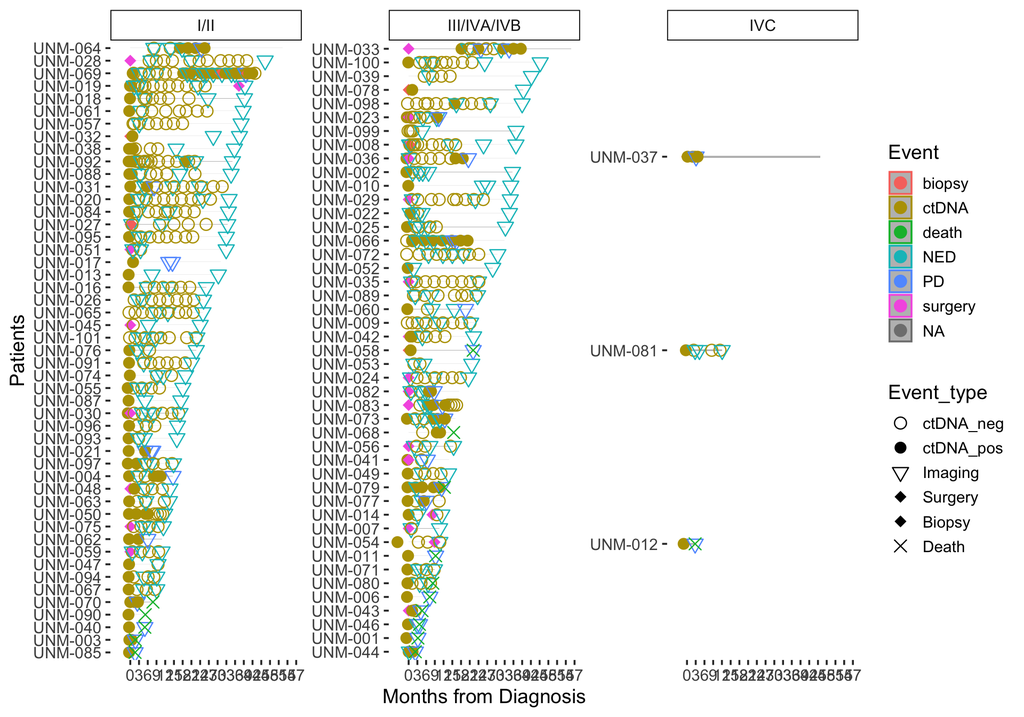

```r
# **Overview plot by Stage**

setwd("~/Downloads")
clinstage <- read.csv("CLIA HNSCC UNM_OP.csv")
clinstage_df <- as.data.frame(clinstage)

# Creating the basic swimmer plot
oplot <- swimmer_plot(df=clinstage_df,
                      id='PatientName',
                      end='fu.diff.months',
                      fill='gray',
                      width=.01,
                      base_size = 14,
                      stratify= c('Stage'))

# Adding themes and scales
oplot <- oplot + theme(panel.border = element_blank())
oplot <- oplot + scale_y_continuous(breaks = seq(0, 72, by = 3))
oplot <- oplot + labs(x ="Patients", y="Months from Diagnosis")

# Adding swimmer points
oplot_ev1 <- oplot + swimmer_points(df_points=clinstage_df,
                                    id='PatientName',
                                    time='date.diff.months',
                                    name_shape ='Event_type',
                                    name_col = 'Event',
                                    size=3.5,fill='black')
# Optionally uncomment and use col='darkgreen' if needed

# Adding shape manual scale
oplot_ev1.1 <- oplot_ev1 + ggplot2::scale_shape_manual(name="Event_type",
                                                       values=c(1,16,6,18,18,4),
                                                       breaks=c('ctDNA_neg','ctDNA_pos', 'Imaging','Surgery','Biopsy', 'Death'))

# Display the plot
oplot_ev1.1
```

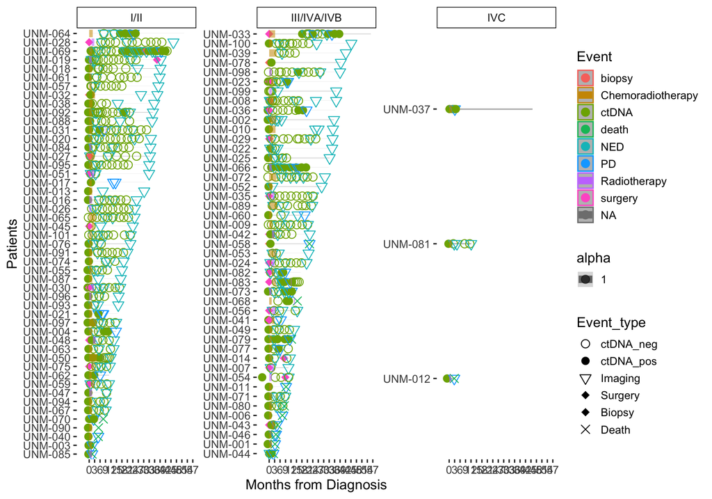

```r
oplot_ev2 <- oplot_ev1.1 + swimmer_lines(df_lines=clinstage_df,
                                         id='PatientName',
                                         start='Tx_start.months',
                                         end='Tx_end.months',
                                         name_col='Tx_type',
                                         size=3.5,
                                         name_alpha = 1.0)
oplot_ev2 <- oplot_ev2 + guides(linetype = guide_legend(override.aes = list(size = 5, color = "black")))
oplot_ev2
```

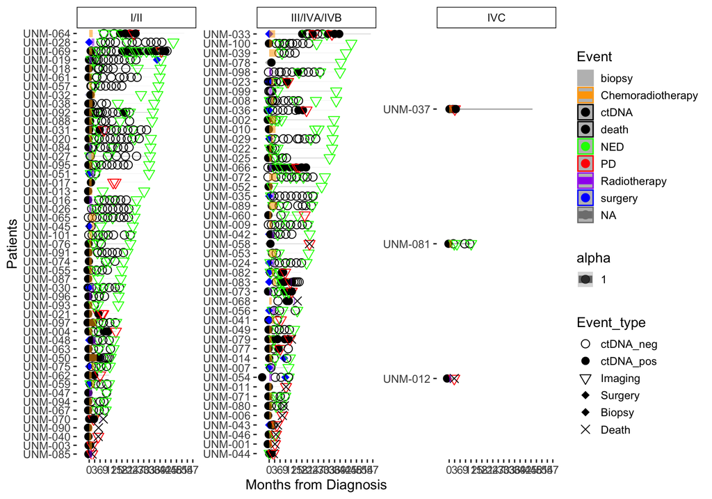

```r
oplot_ev2.2 <- oplot_ev2 + ggplot2::scale_color_manual(name="Event",values=c( "grey", "orange", "black", "black", "green", "red", "purple", "blue"))
oplot_ev2.2
```

# 3. Miscellaneous cohort characteristics and analysis

- **Overall survival metrics for cohort** — PFS and OS estimates for complete cohort (n = 97)
- **ctDNA time points and imaging assessment cadence** — Median of median interval of ctDNA timepoints and radiological imaging assessment

```r
# **PFS in Complete Cohort (N=97)**

rm(list=ls())
setwd("~/Downloads")
circ_data <- read.csv("CLIA HNSCC Peddada Clinical Data.csv")
circ_data <- circ_data[circ_data$ctDNA.available=="TRUE",]

survfit(Surv(time = circ_data$PFS.months, event = circ_data$PFS.Event)~ctDNA.available, data = circ_data)
```

```
## Call: survfit(formula = Surv(time = circ_data$PFS.months, event = circ_data$PFS.Event) ~
##     ctDNA.available, data = circ_data)
##
##       n events median 0.95LCL 0.95UCL
## [1,] 97     34   40.1    40.1      NA
```

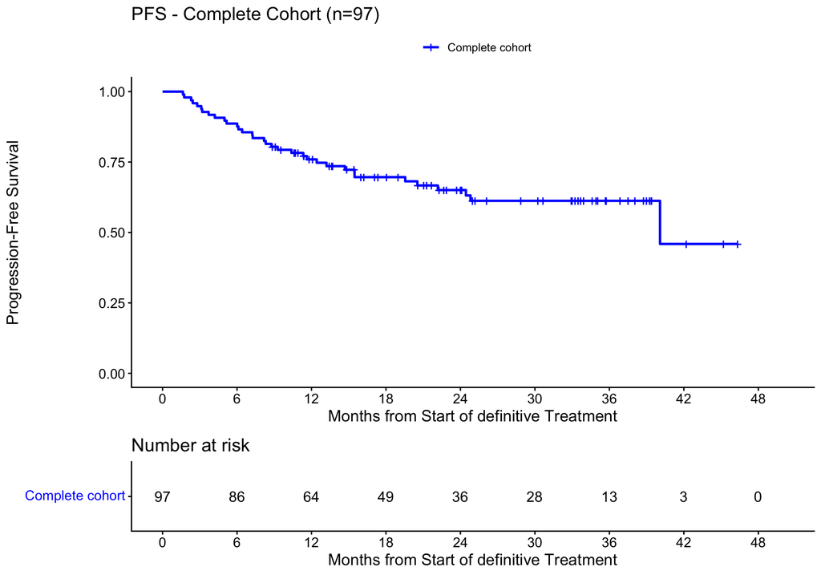

```r
surv_object <-Surv(time = circ_data$PFS.months, event = circ_data$PFS.Event)
KM_curve <- survfit(surv_object ~ ctDNA.available, data = circ_data,conf.int=0.95,conf.type="log-log")
ggsurvplot(KM_curve, data = circ_data, pval = FALSE, conf.int = FALSE, risk.table = TRUE, break.time.by=6, palette=c("blue"), title="PFS - Complete Cohort (n=97)", ylab= "Progression-Free Survival", xlab="Months from Start of definitive Treatment", legend.labs=c("Complete cohort"), legend.title="")
```

```r
summary(KM_curve, times= c(12, 24, 36))
```

```
## Call: survfit(formula = surv_object ~ ctDNA.available, data = circ_data,
##     conf.int = 0.95, conf.type = "log-log")
##
##  time n.risk n.event survival std.err lower 95% CI upper 95% CI
##    12     64      23    0.760  0.0438        0.660        0.833
##    24     36       8    0.651  0.0520        0.538        0.742
##    36     13       2    0.612  0.0555        0.494        0.711
```

```r
# **OS in Complete Cohort (N=97)**

rm(list=ls())
setwd("~/Downloads")
circ_data <- read.csv("CLIA HNSCC Peddada Clinical Data.csv")
circ_data <- circ_data[circ_data$ctDNA.available=="TRUE",]

survfit(Surv(time = circ_data$OS.months, event = circ_data$OS.Event)~ctDNA.available, data = circ_data)
```

```
## Call: survfit(formula = Surv(time = circ_data$OS.months, event = circ_data$OS.Event) ~
##     ctDNA.available, data = circ_data)
##
##       n events median 0.95LCL 0.95UCL
## [1,] 97     16     NA      NA      NA
```

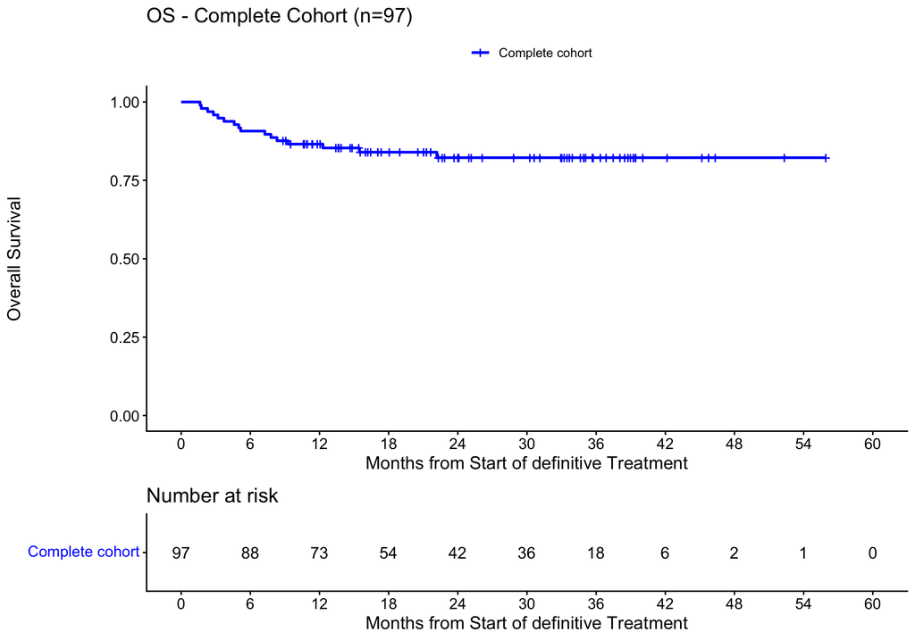

```r
surv_object <-Surv(time = circ_data$OS.months, event = circ_data$OS.Event)
KM_curve <- survfit(surv_object ~ ctDNA.available, data = circ_data,conf.int=0.95,conf.type="log-log")
ggsurvplot(KM_curve, data = circ_data, pval = FALSE, conf.int = FALSE, risk.table = TRUE, break.time.by=6, palette=c("blue"), title="OS - Complete Cohort (n=97)", ylab= "Overall Survival", xlab="Months from Start of definitive Treatment", legend.labs=c("Complete cohort"), legend.title="")
```

```r
summary(KM_curve, times= c(12, 24, 36))
```

```
## Call: survfit(formula = surv_object ~ ctDNA.available, data = circ_data,
##     conf.int = 0.95, conf.type = "log-log")
##
##  time n.risk n.event survival std.err lower 95% CI upper 95% CI
##    12     73      13    0.866  0.0347        0.780        0.920
##    24     42       3    0.822  0.0412        0.724        0.888
##    36     18       0    0.822  0.0412        0.724        0.888
```

```r
# **Median of median interval of ctDNA timepoints and radiological imaging assessment**

rm(list=ls())
setwd("~/Downloads")
df <- read.csv("CLIA HNSCC UNM_OP.csv", stringsAsFactors = FALSE)

names(df) <- trimws(names(df))

# ---- Helper: compute median interval per patient ----
median_interval_per_patient <- function(data, filter_col, filter_val) {
  data %>%
    filter(!!sym(filter_col) == filter_val) %>%
    arrange(PatientName, date.diff) %>%
    group_by(PatientName) %>%
    mutate(interval = date.diff - lag(date.diff)) %>%
    summarise(median_interval = median(interval, na.rm = TRUE), .groups = "drop") %>%
    mutate(event_group = filter_val)
}

# ---- Compute per-patient medians ----
ctDNA_patient_medians   <- median_interval_per_patient(df, "Event", "ctDNA")
imaging_patient_medians <- median_interval_per_patient(df, "Event_type", "Imaging")

# ---- Function to summarize patient-level medians to cohort-level ----
cohort_summary <- function(patient_data, event_label) {
  # Filter out patients with NA median intervals
  valid_data <- patient_data %>% filter(!is.na(median_interval))

  data.frame(
    Event_Type = event_label,
    Cohort_Median_Frequency = median(valid_data$median_interval, na.rm = TRUE),
    Min_Patient_Median = min(valid_data$median_interval, na.rm = TRUE),
    Max_Patient_Median = max(valid_data$median_interval, na.rm = TRUE),
    Range_Patient_Median = max(valid_data$median_interval, na.rm = TRUE) -
      min(valid_data$median_interval, na.rm = TRUE)
  )
}

# ---- Combine all results ----
results <- bind_rows(
  cohort_summary(ctDNA_patient_medians, "ctDNA"),
  cohort_summary(imaging_patient_medians, "Imaging")
)

# ---- Print cohort-level summary ----
cat("===== Median Frequency (Days) per Cohort =====\n")
```

```
## ===== Median Frequency (Days) per Cohort =====
```

```r
print(results, row.names = FALSE)
```

```
##  Event_Type Cohort_Median_Frequency Min_Patient_Median Max_Patient_Median
##       ctDNA                    88.0                 18                303
##     Imaging                   246.5                 22               1068
##  Range_Patient_Median
##                   285
##                  1046
```

```r
# ---- OPTIONAL: Save patient-level medians ----
patient_level_medians <- bind_rows(ctDNA_patient_medians, imaging_patient_medians)
#write.csv(patient_level_medians, "patient_median_intervals.csv", row.names = FALSE)
```

# 4. Figure 3

Association of Baseline ctDNA MTM levels with clinicopathological factors

```r
# **Association of Baseline ctDNA MTM levels with clinicopathological factors**

rm(list=ls())
setwd("~/Downloads")
circ_data <- read.csv("CLIA HNSCC Peddada Clinical Data.csv")
circ_data <- circ_data[circ_data$ctDNA.available=="TRUE",]
circ_data <- circ_data[circ_data$ctDNA.Base!="",]
circ_datadf <- as.data.frame(circ_data)

tally(~cStage, data=circ_data, margins = TRUE)
```

```
## cStage
##   I/II III/IV  Total
##     34     29     63
```

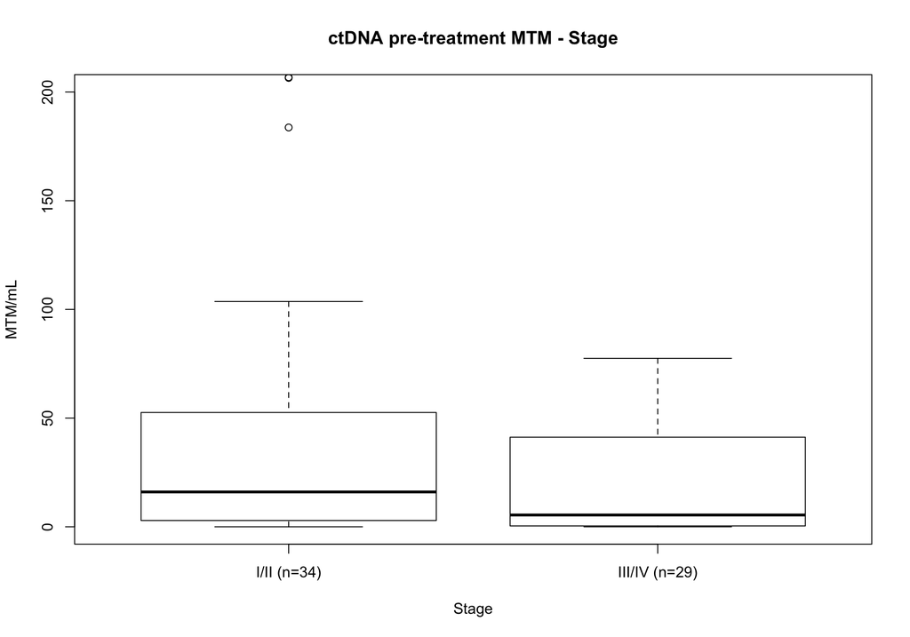

```r
circ_data$cStage <- factor(circ_data$cStage, levels = c("I/II","III/IV"), labels = c("I/II (n=34)","III/IV (n=29)"))
boxplot(ctDNA.Base.MTM~cStage, data=circ_data, main="ctDNA pre-treatment MTM - Stage", xlab="Stage", ylab="MTM/mL", col="white",border="black", ylim = c(0, 200))
```

```r
median_ctDNA.Stage <- circ_data %>%
  group_by(cStage) %>%
  summarise(median_ctDNA_Base_MTM = median(ctDNA.Base.MTM, na.rm = TRUE))
print(median_ctDNA.Stage)
```

```
## # A tibble: 2 × 2
##   cStage        median_ctDNA_Base_MTM
##   <fct>                         <dbl>
## 1 I/II (n=34)                   16.0
## 2 III/IV (n=29)                  5.43
```

```r
m1<-wilcox.test(ctDNA.Base.MTM ~ cStage, data=circ_data, na.rm=TRUE, exact=FALSE, conf.int=TRUE)
print(m1)
```

```
##
##  Wilcoxon rank sum test with continuity correction
##
## data:  ctDNA.Base.MTM by cStage
## W = 601, p-value = 0.138
## alternative hypothesis: true location shift is not equal to 0
## 95 percent confidence interval:
##  -1.04003 17.95005
## sample estimates:
## difference in location
##               3.110541
```

```r
rm(list=ls())
setwd("~/Downloads")
circ_data <- read.csv("CLIA HNSCC Peddada Clinical Data.csv")
circ_data <- circ_data[circ_data$ctDNA.available=="TRUE",]
circ_data <- circ_data[circ_data$ctDNA.Base!="",]
circ_datadf <- as.data.frame(circ_data)

tally(~cT.status, data=circ_data, margins = TRUE)
```

```
## cT.status
## T0-T2 T3-T4 Total
##    29    34    63
```

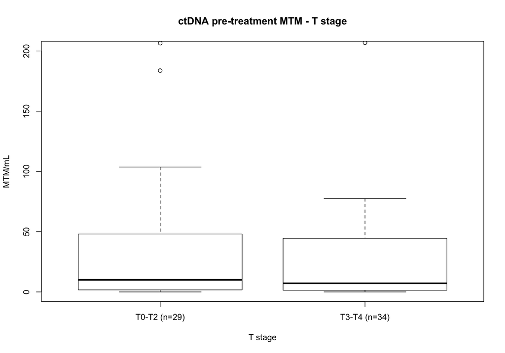

```r
circ_data$cT.status <- factor(circ_data$cT.status, levels = c("T0-T2","T3-T4"), labels = c("T0-T2 (n=29)","T3-T4 (n=34)"))
boxplot(ctDNA.Base.MTM~cT.status, data=circ_data, main="ctDNA pre-treatment MTM - T stage", xlab="T stage", ylab="MTM/mL", col="white",border="black", ylim = c(0, 200))
```

```r
median_ctDNA.cT <- circ_data %>%
  group_by(cT.status) %>%
  summarise(median_ctDNA_Base_MTM = median(ctDNA.Base.MTM, na.rm = TRUE))
print(median_ctDNA.cT)
```

```
## # A tibble: 2 × 2
##   cT.status    median_ctDNA_Base_MTM
##   <fct>                        <dbl>
## 1 T0-T2 (n=29)                 10.0
## 2 T3-T4 (n=34)                  7.15
```

```r
m2<-wilcox.test(ctDNA.Base.MTM ~ cT.status, data=circ_data, na.rm=TRUE, exact=FALSE, conf.int=TRUE)
print(m2)
```

```
##
##  Wilcoxon rank sum test with continuity correction
##
## data:  ctDNA.Base.MTM by cT.status
## W = 489, p-value = 0.9615
## alternative hypothesis: true location shift is not equal to 0
## 95 percent confidence interval:
##  -7.720014  8.029990
## sample estimates:
## difference in location
##          -4.450499e-05
```

```r
rm(list=ls())
setwd("~/Downloads")
circ_data <- read.csv("CLIA HNSCC Peddada Clinical Data.csv")
circ_data <- circ_data[circ_data$ctDNA.available=="TRUE",]
circ_data <- circ_data[circ_data$ctDNA.Base!="",]
circ_datadf <- as.data.frame(circ_data)

tally(~cT, data=circ_data, margins = TRUE)
```

```
## cT
##    T0    T1    T2    T3    T4 Total
##     2     5    22    21    13    63
```

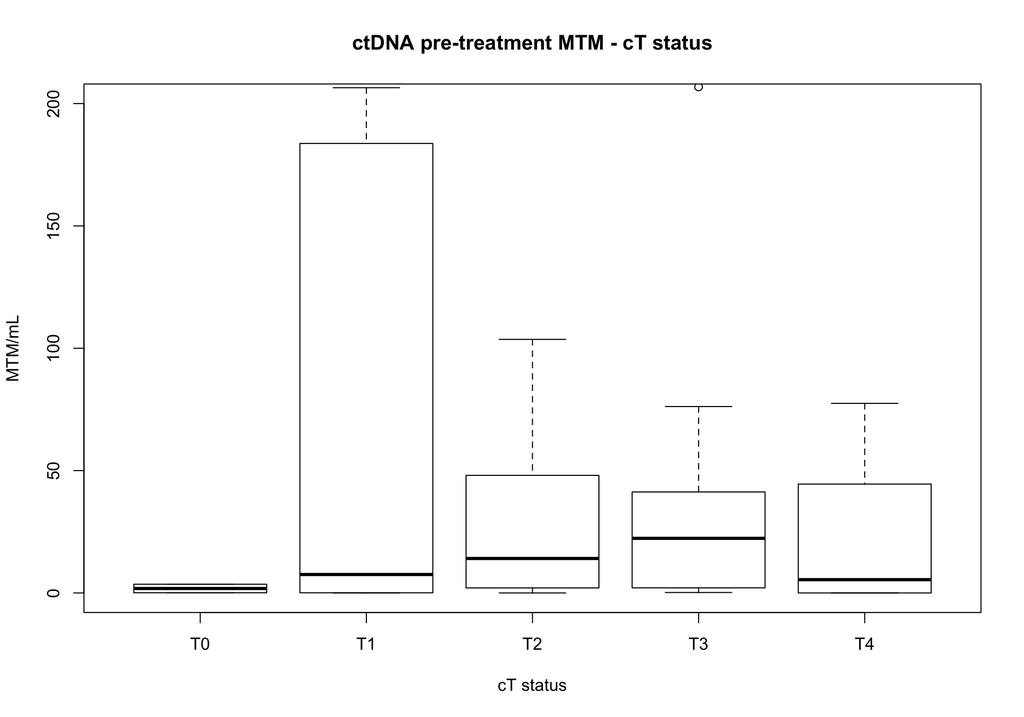

```r
circ_data$cT <- factor(circ_data$cT, levels = c("T0","T1","T2","T3","T4"))
boxplot(ctDNA.Base.MTM~cT, data=circ_data, main="ctDNA pre-treatment MTM - cT status", xlab="cT status", ylab="MTM/mL", col="white",border="black", ylim = c(0, 200))
```

```r
median_ctDNA.cT <- circ_data %>%
  group_by(cT) %>%
  summarise(median_ctDNA_Base_MTM = median(ctDNA.Base.MTM, na.rm = TRUE))
print(median_ctDNA.cT)
```

```
## # A tibble: 5 × 2
##   cT    median_ctDNA_Base_MTM
##   <fct>                 <dbl>
## 1 T0                     1.82
## 2 T1                     7.54
## 3 T2                    14.1
## 4 T3                    22.3
## 5 T4                     5.43
```

```r
pairwise_wilcox <- pairwise.wilcox.test(circ_data$ctDNA.Base.MTM, circ_data$cT,
                                        p.adjust.method = "none",
                                        exact = FALSE)
print(pairwise_wilcox)
```

```
##
##  Pairwise comparisons using Wilcoxon rank sum test with continuity correction
##
## data:  circ_data$ctDNA.Base.MTM and circ_data$cT
##
##    T0   T1   T2   T3
## T1 0.85 -    -    -
## T2 0.19 0.83 -    -
## T3 0.14 0.65 0.76 -
## T4 0.55 0.62 0.33 0.23
##
## P value adjustment method: none
```

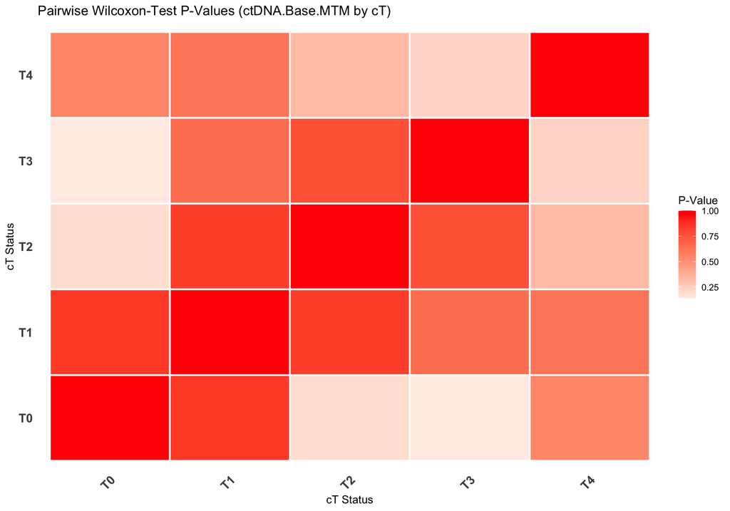

```r
rm(list=ls())
setwd("~/Downloads")
circ_data <- read.csv("CLIA HNSCC Peddada Clinical Data.csv")
circ_data <- circ_data[circ_data$ctDNA.available == "TRUE",]
circ_data <- circ_data[circ_data$ctDNA.Base != "",]
circ_data$cT <- factor(circ_data$cT, levels = c("T0", "T1", "T2", "T3", "T4"))
circ_data$ctDNA.Base.MTM <- as.numeric(circ_data$ctDNA.Base.MTM)
cT_levels <- levels(circ_data$cT)
p_value_matrix <- matrix(NA, nrow = length(cT_levels), ncol = length(cT_levels))
rownames(p_value_matrix) <- cT_levels
colnames(p_value_matrix) <- cT_levels

for (i in 1:length(cT_levels)) {
  for (j in i:length(cT_levels)) {
    if (i != j) {
      # Extract data for both groups
      data1 <- circ_data %>% filter(cT == cT_levels[i]) %>% pull(ctDNA.Base.MTM)
      data2 <- circ_data %>% filter(cT == cT_levels[j]) %>% pull(ctDNA.Base.MTM)

      # Perform Wilcoxon test and store p-value
      test_result <- wilcox.test(data1, data2, exact = FALSE)
      p_value_matrix[i, j] <- test_result$p.value
      p_value_matrix[j, i] <- test_result$p.value  # Make symmetric
    } else {
      p_value_matrix[i, j] <- 1  # Self-comparison = 1
    }
  }
}

p_value_matrix[is.na(p_value_matrix)] <- 1.00
p_value_data <- melt(p_value_matrix)
colnames(p_value_data) <- c("cT1", "cT2", "p_value")
p_value_data <- p_value_data %>%
  mutate(
    significance = case_when(
      p_value < 0.001 ~ "***",
      p_value < 0.01 ~ "**",
      p_value < 0.05 ~ "*",
      TRUE ~ ""
    )
  )

ggplot(p_value_data, aes(x = cT1, y = cT2, fill = p_value)) +
  geom_tile(color = "white", size = 0.8) +  # Thicker grid lines for separation
  geom_text(aes(label = significance), color = "black", size = 6, fontface = "bold") +  # Significance markers
  scale_fill_gradient2(low = "blue", mid = "white", high = "red", midpoint = 0.05) +  # Gradient colors
  theme_minimal() +
  theme(axis.text.x = element_text(angle = 45, hjust = 1, size = 12, face = "bold"),
        axis.text.y = element_text(size = 12, face = "bold"),
        panel.grid = element_blank()) +
  labs(title = "Pairwise Wilcoxon-Test P-Values (ctDNA.Base.MTM by cT)",
       x = "cT Status", y = "cT Status", fill = "P-Value")
```

```r
rm(list=ls())
setwd("~/Downloads")
circ_data <- read.csv("CLIA HNSCC Peddada Clinical Data.csv")
circ_data <- circ_data[circ_data$ctDNA.available=="TRUE",]
circ_data <- circ_data[circ_data$ctDNA.Base!="",]
circ_datadf <- as.data.frame(circ_data)

tally(~cN.status, data=circ_data, margins = TRUE)
```

```
## cN.status
##    N0 N1-N3 Total
##    12    51    63
```

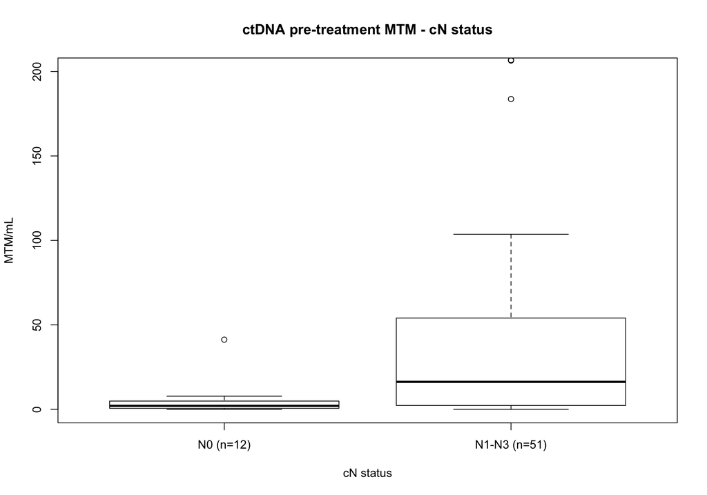

```r
circ_data$cN.status <- factor(circ_data$cN.status, levels = c("N0","N1-N3"), labels = c("N0 (n=12)","N1-N3 (n=51)"))
boxplot(ctDNA.Base.MTM~cN.status, data=circ_data, main="ctDNA pre-treatment MTM - cN status", xlab="cN status", ylab="MTM/mL", col="white",border="black", ylim = c(0, 200))
```

```r
median_ctDNA.cN <- circ_data %>%
  group_by(cN.status) %>%
  summarise(median_ctDNA_Base_MTM = median(ctDNA.Base.MTM, na.rm = TRUE))
print(median_ctDNA.cN)
```

```
## # A tibble: 2 × 2
##   cN.status    median_ctDNA_Base_MTM
##   <fct>                        <dbl>
## 1 N0 (n=12)                     2.06
## 2 N1-N3 (n=51)                 16.3
```

```r
m3<-wilcox.test(ctDNA.Base.MTM ~ cN.status, data=circ_data, na.rm=TRUE, exact=FALSE, conf.int=TRUE)
print(m3)
```

```
##
##  Wilcoxon rank sum test with continuity correction
##
## data:  ctDNA.Base.MTM by cN.status
## W = 163, p-value = 0.01256
## alternative hypothesis: true location shift is not equal to 0
## 95 percent confidence interval:
##  -41.019963  -1.190095
## sample estimates:
## difference in location
##              -11.93637
```

```r
rm(list=ls())
setwd("~/Downloads")
circ_data <- read.csv("CLIA HNSCC Peddada Clinical Data.csv")
circ_data <- circ_data[circ_data$ctDNA.available=="TRUE",]
circ_data <- circ_data[circ_data$ctDNA.Base!="",]
circ_datadf <- as.data.frame(circ_data)

tally(~cN, data=circ_data, margins = TRUE)
```

```
## cN
##    N0    N1    N2    N3 Total
##    12    22    23     6    63
```

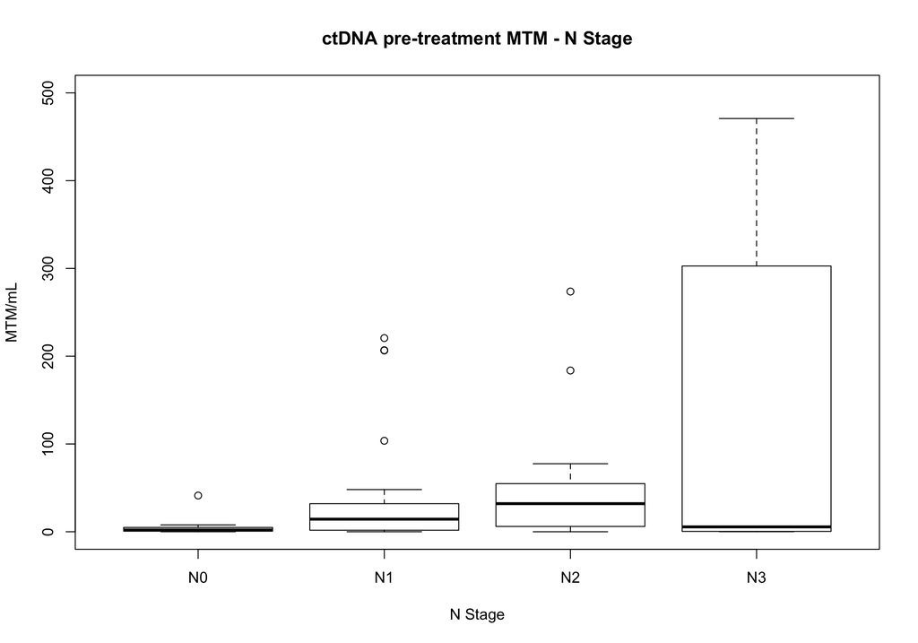

```r
circ_data$cN <- factor(circ_data$cN, levels = c("N0","N1","N2","N3"))
boxplot(ctDNA.Base.MTM~cN, data=circ_data, main="ctDNA pre-treatment MTM - N Stage", xlab="N Stage", ylab="MTM/mL", col="white",border="black", ylim = c(0, 500))
```

```r
median_ctDNA.cN <- circ_data %>%
  group_by(cN) %>%
  summarise(median_ctDNA_Base_MTM = median(ctDNA.Base.MTM, na.rm = TRUE))
print(median_ctDNA.cN)
```

```
## # A tibble: 4 × 2
##   cN    median_ctDNA_Base_MTM
##   <fct>                 <dbl>
## 1 N0                     2.06
## 2 N1                    14.3
## 3 N2                    32.0
## 4 N3                     5.55
```

```r
pairwise_wilcox <- pairwise.wilcox.test(circ_data$ctDNA.Base.MTM, circ_data$cN,
                                        p.adjust.method = "none",
                                        exact = FALSE)
print(pairwise_wilcox)
```

```
##
##  Pairwise comparisons using Wilcoxon rank sum test with continuity correction
##
## data:  circ_data$ctDNA.Base.MTM and circ_data$cN
##
##    N0     N1     N2
## N1 0.0473 -      -
## N2 0.0074 0.3513 -
## N3 0.3736 0.9777 0.7262
##
## P value adjustment method: none
```

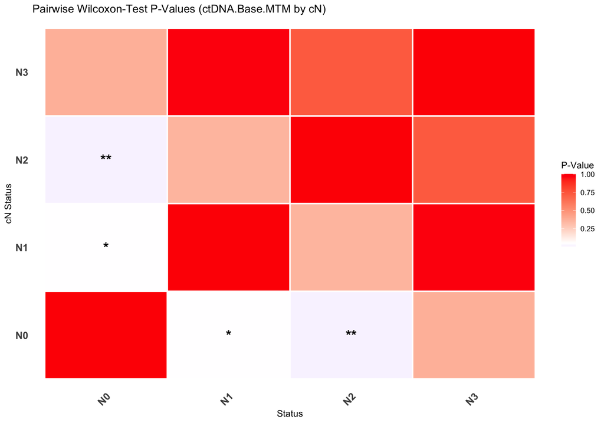

```r
rm(list=ls())
setwd("~/Downloads")
circ_data <- read.csv("CLIA HNSCC Peddada Clinical Data.csv")
circ_data <- circ_data[circ_data$ctDNA.available == "TRUE",]
circ_data <- circ_data[circ_data$ctDNA.Base != "",]
circ_data$cN <- factor(circ_data$cN, levels = c("N0","N1","N2","N3"))
circ_data$ctDNA.Base.MTM <- as.numeric(circ_data$ctDNA.Base.MTM)
cN_levels <- levels(circ_data$cN)
p_value_matrix <- matrix(NA, nrow = length(cN_levels), ncol = length(cN_levels))
rownames(p_value_matrix) <- cN_levels
colnames(p_value_matrix) <- cN_levels

for (i in 1:length(cN_levels)) {
  for (j in i:length(cN_levels)) {
    if (i != j) {
      # Extract data for both groups
      data1 <- circ_data %>% filter(cN == cN_levels[i]) %>% pull(ctDNA.Base.MTM)
      data2 <- circ_data %>% filter(cN == cN_levels[j]) %>% pull(ctDNA.Base.MTM)

      # Perform Wilcoxon test and store p-value
      test_result <- wilcox.test(data1, data2, exact = FALSE)
      p_value_matrix[i, j] <- test_result$p.value
      p_value_matrix[j, i] <- test_result$p.value  # Make symmetric
    } else {
      p_value_matrix[i, j] <- 1  # Self-comparison = 1
    }
  }
}

p_value_matrix[is.na(p_value_matrix)] <- 1.00
p_value_data <- melt(p_value_matrix)
colnames(p_value_data) <- c("cN1", "cN2", "p_value")
p_value_data <- p_value_data %>%
  mutate(
    significance = case_when(
      p_value < 0.001 ~ "***",
      p_value < 0.01 ~ "**",
      p_value < 0.05 ~ "*",
      TRUE ~ ""
    )
  )

ggplot(p_value_data, aes(x = cN1, y = cN2, fill = p_value)) +
  geom_tile(color = "white", size = 0.8) +  # Thicker grid lines for separation
  geom_text(aes(label = significance), color = "black", size = 6, fontface = "bold") +  # Significance markers
  scale_fill_gradient2(low = "blue", mid = "white", high = "red", midpoint = 0.05) +  # Gradient colors
  theme_minimal() +
  theme(axis.text.x = element_text(angle = 45, hjust = 1, size = 12, face = "bold"),
        axis.text.y = element_text(size = 12, face = "bold"),
        panel.grid = element_blank()) +
  labs(title = "Pairwise Wilcoxon-Test P-Values (ctDNA.Base.MTM by cN)",
       x = "Status", y = "cN Status", fill = "P-Value")
```

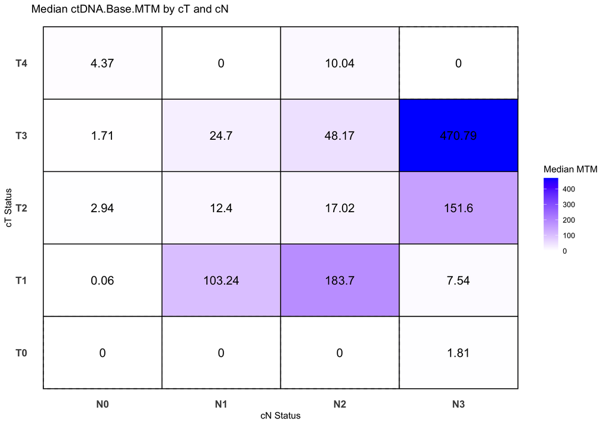

```r
rm(list=ls())
setwd("~/Downloads")
circ_data <- read.csv("CLIA HNSCC Peddada Clinical Data.csv")
circ_data <- circ_data[circ_data$ctDNA.available == "TRUE",]
circ_data <- circ_data[circ_data$ctDNA.Base != "",]
circ_data$cT <- factor(circ_data$cT, levels = c("T0", "T1", "T2", "T3", "T4"))
circ_data$cN <- factor(circ_data$cN, levels = c("N0", "N1", "N2", "N3"))
circ_data$ctDNA.Base.MTM <- as.numeric(circ_data$ctDNA.Base.MTM)

median_ctDNA <- circ_data %>%
  group_by(cT, cN) %>%
  summarise(median_ctDNA_Base_MTM = median(ctDNA.Base.MTM, na.rm = TRUE)) %>%
  ungroup()

p_value_matrix <- dcast(median_ctDNA, cT ~ cN, value.var = "median_ctDNA_Base_MTM")
p_value_data <- melt(p_value_matrix, id.vars = "cT", variable.name = "cN", value.name = "median_value")
p_value_data$missing <- ifelse(is.na(p_value_data$median_value), "Missing", "Present")
p_value_data$median_value[is.na(p_value_data$median_value)] <- 0

ggplot(p_value_data, aes(x = cN, y = cT, fill = median_value)) +
  geom_tile(color = "black", size = 0.5) +  # Black gridlines for separation
  geom_text(aes(label = round(median_value, 2)), color = "black", size = 5) +  # Display median values
  scale_fill_gradient(low = "white", high = "blue") +  # Color gradient similar to the reference image
  theme_minimal() +
  theme(axis.text.x = element_text(size = 12, face = "bold"),
        axis.text.y = element_text(size = 12, face = "bold"),
        panel.grid = element_blank()) +
  labs(title = "Median ctDNA.Base.MTM by cT and cN",
       x = "cN Status", y = "cT Status", fill = "Median MTM") +
  geom_tile(data = subset(p_value_data, missing == "Missing"),
            aes(x = cN, y = cT), color = "black", fill = NA, size = 0.5, linetype = "dashed")  # Add diagonal cross for missing values
```

```r
rm(list=ls())
setwd("~/Downloads")
circ_data <- read.csv("CLIA HNSCC Peddada Clinical Data.csv")
circ_data <- circ_data[circ_data$ctDNA.available=="TRUE",]
circ_data <- circ_data[circ_data$ctDNA.Base!="",]
circ_datadf <- as.data.frame(circ_data)

tally(~cM, data=circ_data, margins = TRUE)
```

```
## cM
##    M0    M1 Total
##    61     2    63
```

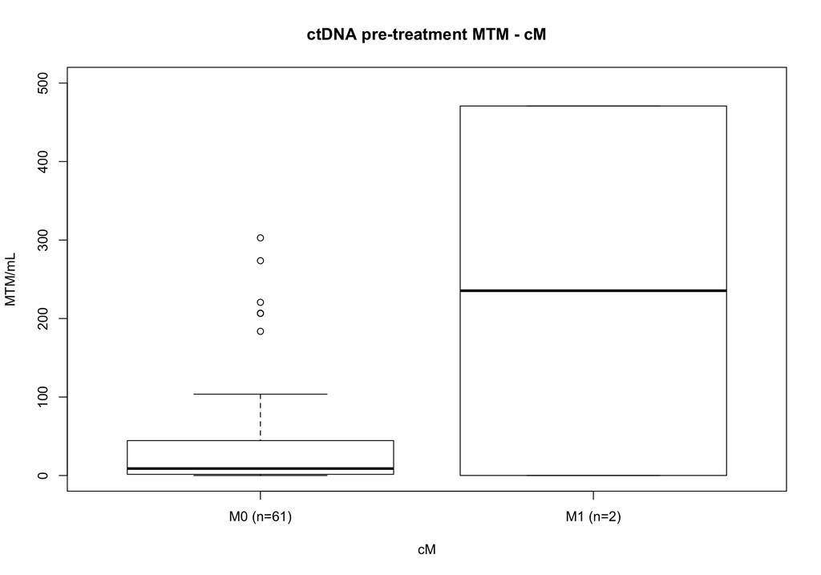

```r
circ_data$cM <- factor(circ_data$cM, levels = c("M0","M1"), labels = c("M0 (n=61)","M1 (n=2)"))
boxplot(ctDNA.Base.MTM~cM, data=circ_data, main="ctDNA pre-treatment MTM - cM", xlab="cM", ylab="MTM/mL", col="white",border="black", ylim = c(0, 500))
```

```r
median_ctDNA.cM <- circ_data %>%
  group_by(cM) %>%
  summarise(median_ctDNA_Base_MTM = median(ctDNA.Base.MTM, na.rm = TRUE))
print(median_ctDNA.cM)
```

```
## # A tibble: 2 × 2
##   cM        median_ctDNA_Base_MTM
##   <fct>                     <dbl>
## 1 M0 (n=61)                  8.84
## 2 M1 (n=2)                 235.
```

```r
m4<-wilcox.test(ctDNA.Base.MTM ~ cM, data=circ_data, na.rm=TRUE, exact=FALSE, conf.int=TRUE)
print(m4)
```

```
##
##  Wilcoxon rank sum test with continuity correction
##
## data:  ctDNA.Base.MTM by cM
## W = 54, p-value = 0.7987
## alternative hypothesis: true location shift is not equal to 0
## 95 percent confidence interval:
##  -469.97996   76.10995
## sample estimates:
## difference in location
##            -0.07005084
```

```r
rm(list=ls())
setwd("~/Downloads")
circ_data <- read.csv("CLIA HNSCC Peddada Clinical Data.csv")
circ_data <- circ_data[circ_data$ctDNA.available=="TRUE",]
circ_data <- circ_data[circ_data$ctDNA.Base!="",]
circ_datadf <- as.data.frame(circ_data)

tally(~p16.status, data=circ_data, margins = TRUE)
```

```
## p16.status
## Negative Positive    Total
##       24       39       63
```

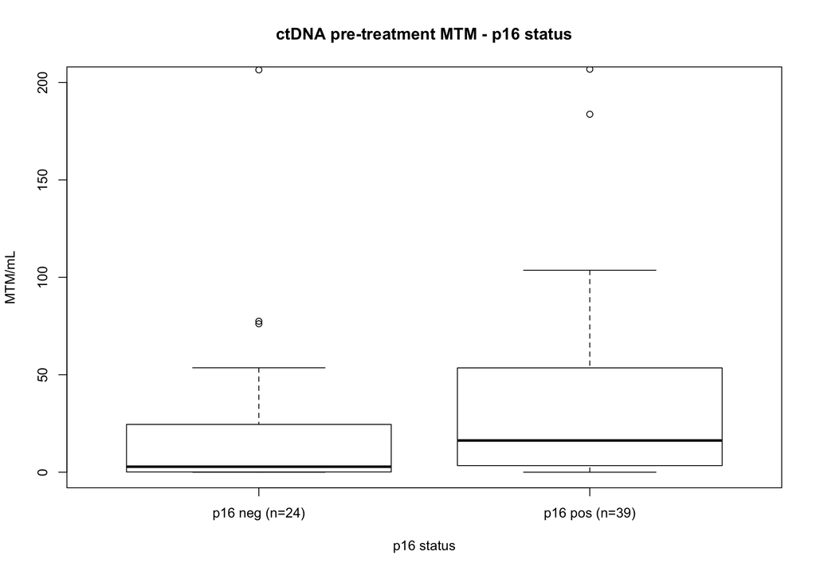

```r
circ_data$p16.status <- factor(circ_data$p16.status, levels = c("Negative","Positive"), labels = c("p16 neg (n=24)","p16 pos (n=39)"))
boxplot(ctDNA.Base.MTM~p16.status, data=circ_data, main="ctDNA pre-treatment MTM - p16 status", xlab="p16 status", ylab="MTM/mL", col="white",border="black", ylim = c(0, 200))
```

```r
median_ctDNA.p16 <- circ_data %>%
  group_by(p16.status) %>%
  summarise(median_ctDNA_Base_MTM = median(ctDNA.Base.MTM, na.rm = TRUE))
print(median_ctDNA.p16)
```

```
## # A tibble: 2 × 2
##   p16.status     median_ctDNA_Base_MTM
##   <fct>                          <dbl>
## 1 p16 neg (n=24)                  2.82
## 2 p16 pos (n=39)                 16.3
```

```r
m5<-wilcox.test(ctDNA.Base.MTM ~ p16.status, data=circ_data, na.rm=TRUE, exact=FALSE, conf.int=TRUE)
print(m5)
```

```
##
##  Wilcoxon rank sum test with continuity correction
##
## data:  ctDNA.Base.MTM by p16.status
## W = 294, p-value = 0.014
## alternative hypothesis: true location shift is not equal to 0
## 95 percent confidence interval:
##  -27.0900146  -0.8600542
## sample estimates:
## difference in location
##              -8.507328
```

```r
rm(list=ls())
setwd("~/Downloads")
circ_data <- read.csv("CLIA HNSCC Peddada Clinical Data.csv")
circ_data <- circ_data[circ_data$ctDNA.available=="TRUE",]
circ_data <- circ_data[circ_data$ctDNA.Base!="",]
circ_datadf <- as.data.frame(circ_data)

tally(~Prim.Location, data=circ_data, margins = TRUE)
```

```
## Prim.Location
##                         Larynx/Hypopharynx
##                                          3
##                                Oral cavity
##                                          8
##                                 Oropharynx
##                                         47
## Other (paranasal sinus and nasopharyngeal)
##                                          5
##                                      Total
##                                         63
```

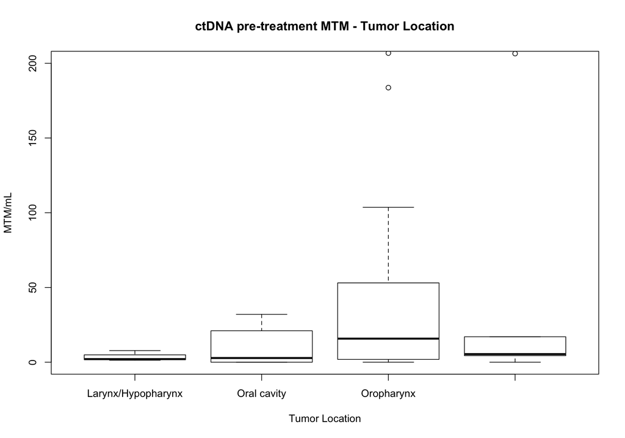

```r
circ_data$Prim.Location <- factor(circ_data$Prim.Location, levels = c("Larynx/Hypopharynx","Oral cavity", "Oropharynx", "Other (paranasal sinus and nasopharyngeal)"))
boxplot(ctDNA.Base.MTM~Prim.Location, data=circ_data, main="ctDNA pre-treatment MTM - Tumor Location", xlab="Tumor Location", ylab="MTM/mL", col="white",border="black", ylim = c(0, 200))
```

```r
median_ctDNA.loc <- circ_data %>%
  group_by(Prim.Location) %>%
  summarise(median_ctDNA_Base_MTM = median(ctDNA.Base.MTM, na.rm = TRUE))
print(median_ctDNA.loc)
```

```
## # A tibble: 4 × 2
##   Prim.Location                              median_ctDNA_Base_MTM
##   <fct>                                                      <dbl>
## 1 Larynx/Hypopharynx                                          2.08
## 2 Oral cavity                                                 2.81
## 3 Oropharynx                                                 15.8
## 4 Other (paranasal sinus and nasopharyngeal)                  5.43
```

```r
pairwise_wilcox <- pairwise.wilcox.test(circ_data$ctDNA.Base.MTM, circ_data$Prim.Location,
                                        p.adjust.method = "none",
                                        exact = FALSE)

print(pairwise_wilcox)
```

```
##
##  Pairwise comparisons using Wilcoxon rank sum test with continuity correction
##
## data:  circ_data$ctDNA.Base.MTM and circ_data$Prim.Location
##
##                                            Larynx/Hypopharynx Oral cavity
## Oral cavity                                0.92               -
## Oropharynx                                 0.25               0.12
## Other (paranasal sinus and nasopharyngeal) 0.55               0.77
##                                            Oropharynx
## Oral cavity                                -
## Oropharynx                                 -
## Other (paranasal sinus and nasopharyngeal) 0.65
##
## P value adjustment method: none
```

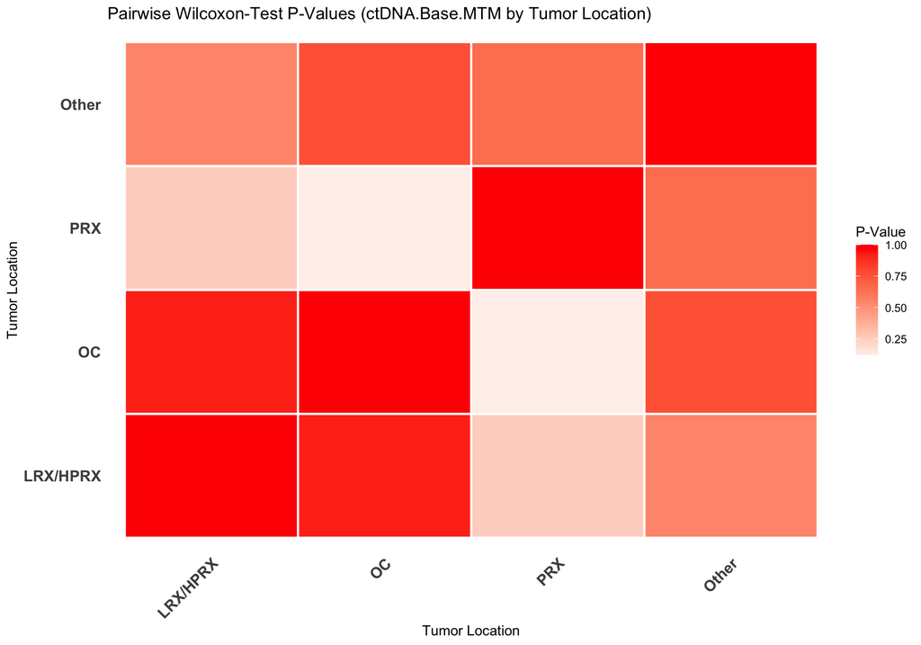

```r
rm(list=ls())
setwd("~/Downloads")
circ_data <- read.csv("CLIA HNSCC Peddada Clinical Data.csv")
circ_data <- circ_data[circ_data$ctDNA.available == "TRUE",]
circ_data <- circ_data[circ_data$ctDNA.Base != "",]
circ_data$Prim.Location <- factor(circ_data$Prim.Location, levels = c("Larynx/Hypopharynx","Oral cavity", "Oropharynx", "Other (paranasal sinus and nasopharyngeal)"), labels = c("LRX/HPRX","OC","PRX","Other"))
circ_data$ctDNA.Base.MTM <- as.numeric(circ_data$ctDNA.Base.MTM)
pl_levels <- levels(circ_data$Prim.Location)
p_value_matrix <- matrix(NA, nrow = length(pl_levels), ncol = length(pl_levels))
rownames(p_value_matrix) <- pl_levels
colnames(p_value_matrix) <- pl_levels

for (i in 1:length(pl_levels)) {
  for (j in i:length(pl_levels)) {
    if (i != j) {
      # Extract data for both groups
      data1 <- circ_data %>% filter(Prim.Location == pl_levels[i]) %>% pull(ctDNA.Base.MTM)
      data2 <- circ_data %>% filter(Prim.Location == pl_levels[j]) %>% pull(ctDNA.Base.MTM)

      # Perform Wilcoxon test and store p-value
      test_result <- wilcox.test(data1, data2, exact = FALSE)
      p_value_matrix[i, j] <- test_result$p.value
      p_value_matrix[j, i] <- test_result$p.value  # Make symmetric
    } else {
      p_value_matrix[i, j] <- 1  # Self-comparison = 1
    }
  }
}

p_value_matrix[is.na(p_value_matrix)] <- 1.00
p_value_data <- melt(p_value_matrix)
colnames(p_value_data) <- c("pl1", "pl2", "p_value")
p_value_data <- p_value_data %>%
  mutate(
    significance = case_when(
      p_value < 0.001 ~ "***",
      p_value < 0.01 ~ "**",
      p_value < 0.05 ~ "*",
      TRUE ~ ""
    )
  )

ggplot(p_value_data, aes(x = pl1, y = pl2, fill = p_value)) +
  geom_tile(color = "white", size = 0.8) +  # Thicker grid lines for separation
  geom_text(aes(label = significance), color = "black", size = 6, fontface = "bold") +  # Significance markers
  scale_fill_gradient2(low = "blue", mid = "white", high = "red", midpoint = 0.05) +  # Gradient colors
  theme_minimal() +
  theme(axis.text.x = element_text(angle = 45, hjust = 1, size = 12, face = "bold"),
        axis.text.y = element_text(size = 12, face = "bold"),
        panel.grid = element_blank()) +
  labs(title = "Pairwise Wilcoxon-Test P-Values (ctDNA.Base.MTM by Tumor Location)",
       x = "Tumor Location", y = "Tumor Location", fill = "P-Value")
```

# 5. Figure 4

Kaplan-Meier estimates of outcomes stratified by ctDNA at MRD status

```r
# **PFS by ctDNA status at MRD**

rm(list=ls())
setwd("~/Downloads")
circ_data <- read.csv("CLIA HNSCC Peddada Clinical Data.csv")
circ_data <- circ_data[circ_data$ctDNA.available=="TRUE",]
circ_data <- circ_data[circ_data$ctDNA.MRD!="",]
circ_datadf <- as.data.frame(circ_data)

survfit(Surv(time = circ_data$PFS.months, event = circ_data$PFS.Event)~ctDNA.MRD, data = circ_data)
```

```
## Call: survfit(formula = Surv(time = circ_data$PFS.months, event = circ_data$PFS.Event) ~
##     ctDNA.MRD, data = circ_data)
##
##                     n events median 0.95LCL 0.95UCL
## ctDNA.MRD=NEGATIVE 56      9     NA   40.08      NA
## ctDNA.MRD=POSITIVE 13      8   15.5    4.21      NA
```

```r
event_summary <- circ_data %>%
  group_by(ctDNA.MRD) %>%
  summarise(
    Total = n(),
    Events = sum(PFS.Event),
    Fraction = Events / n(),
    Percentage = (Events / n()) * 100
  )
print(event_summary)
```

```
## # A tibble: 2 × 5
##   ctDNA.MRD Total Events Fraction Percentage
##   <chr>     <int>  <int>    <dbl>      <dbl>
## 1 NEGATIVE     56      9    0.161       16.1
## 2 POSITIVE     13      8    0.615       61.5
```

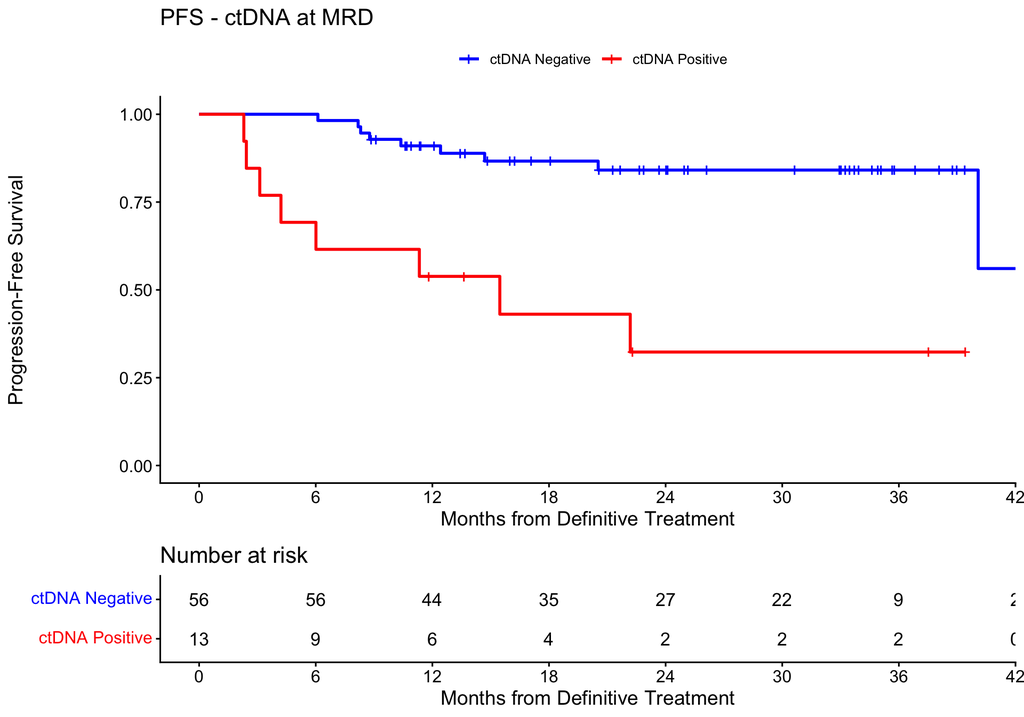

```r
surv_object <-Surv(time = circ_data$PFS.months, event = circ_data$PFS.Event)
KM_curve <- survfit(surv_object ~ ctDNA.MRD, data = circ_data,conf.int=0.95,conf.type="log-log")
ggsurvplot(KM_curve, data = circ_data, pval = FALSE, conf.int = FALSE, risk.table = TRUE, break.time.by=6, palette=c("blue","red"), title="PFS - ctDNA at MRD", ylab= "Progression-Free Survival", xlab="Months from Definitive Treatment", legend.labs=c("ctDNA Negative", "ctDNA Positive"), legend.title="")
```

```r
summary(KM_curve, times= c(0, 12, 24, 36))
```

```
## Call: survfit(formula = surv_object ~ ctDNA.MRD, data = circ_data,
##     conf.int = 0.95, conf.type = "log-log")
##
##                 ctDNA.MRD=NEGATIVE
##  time n.risk n.event survival std.err lower 95% CI upper 95% CI
##     0     56       0    1.000  0.0000        1.000        1.000
##    12     44       5    0.910  0.0384        0.797        0.962
##    24     27       3    0.841  0.0523        0.705        0.918
##    36      9       0    0.841  0.0523        0.705        0.918
##
##                 ctDNA.MRD=POSITIVE
##  time n.risk n.event survival std.err lower 95% CI upper 95% CI
##     0     13       0    1.000   0.000       1.0000        1.000
##    12      6       6    0.538   0.138       0.2477        0.760
##    24      2       2    0.323   0.144       0.0862        0.594
##    36      2       0    0.323   0.144       0.0862        0.594
```

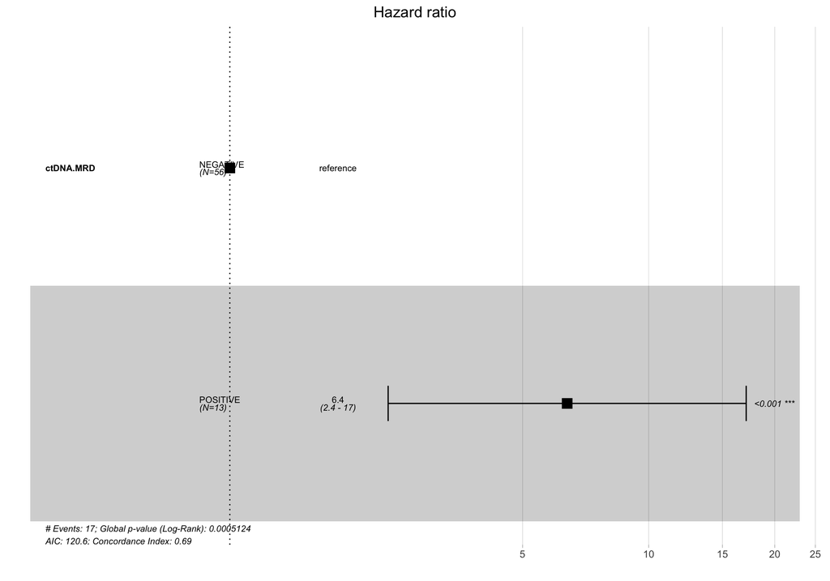

```r
circ_data$ctDNA.MRD <- factor(circ_data$ctDNA.MRD, levels=c("NEGATIVE","POSITIVE"))
cox_fit <- coxph(surv_object ~ ctDNA.MRD, data=circ_data)
ggforest(cox_fit,data = circ_data)
```

```r
summary(cox_fit)
```

```
## Call:
## coxph(formula = surv_object ~ ctDNA.MRD, data = circ_data)
##
##   n= 69, number of events= 17
##
##                     coef exp(coef) se(coef)     z Pr(>|z|)
## ctDNA.MRDPOSITIVE 1.8545    6.3886   0.5021 3.693 0.000221 ***
## ---
## Signif. codes:  0 '***' 0.001 '**' 0.01 '*' 0.05 '.' 0.1 ' ' 1
##
##                   exp(coef) exp(-coef) lower .95 upper .95
## ctDNA.MRDPOSITIVE     6.389     0.1565     2.388     17.09
##
## Concordance= 0.69  (se = 0.059 )
## Likelihood ratio test= 12.07  on 1 df,   p=5e-04
## Wald test            = 13.64  on 1 df,   p=2e-04
## Score (logrank) test = 17.94  on 1 df,   p=2e-05
```

```r
cox_fit_summary <- summary(cox_fit)

#Extract values for HR, 95% CI, and p-value
HR <- cox_fit_summary$coefficients[2]
lower_CI <- cox_fit_summary$conf.int[3]
upper_CI <- cox_fit_summary$conf.int[4]
p_value <- cox_fit_summary$coefficients[5]
label_text <- paste0("HR = ", round(HR, 2), " (", round(lower_CI, 2), "-", round(upper_CI, 2), "); p = ", round(p_value, 3))
print(label_text)
```

```
## [1] "HR = 6.39 (2.39-17.09); p = 0"
```

```r
circ_data$ctDNA.MRD <- factor(circ_data$ctDNA.MRD, levels = c("NEGATIVE", "POSITIVE"), labels = c("Negative", "Positive"))
circ_data$PFS.Event <- factor(circ_data$PFS.Event, levels = c("FALSE", "TRUE"), labels = c("No Progression", "Progression"))
contingency_table <- table(circ_data$ctDNA.MRD, circ_data$PFS.Event)
chi_square_test <- chisq.test(contingency_table)
print(chi_square_test)
```

```
##
##  Pearson's Chi-squared test with Yates' continuity correction
##
## data:  contingency_table
## X-squared = 9.4257, df = 1, p-value = 0.00214
```

```r
fisher_exact_test <- fisher.test(contingency_table)
print(fisher_exact_test)
```

```
##
##  Fisher's Exact Test for Count Data
##
## data:  contingency_table
## p-value = 0.001816
## alternative hypothesis: true odds ratio is not equal to 1
## 95 percent confidence interval:
##   1.839047 39.292099
## sample estimates:
## odds ratio
##   8.005348
```

```r
print(contingency_table)
```

```
##
##            No Progression Progression
##   Negative             47           9
##   Positive              5           8
```

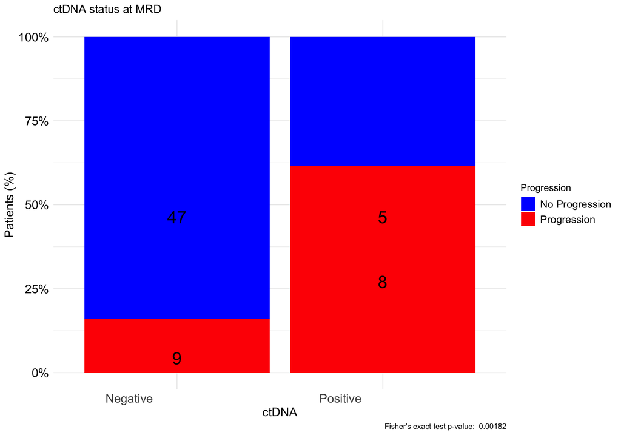

```r
table_df <- as.data.frame(contingency_table)
table_df$Total <- ave(table_df$Freq, table_df$Var1, FUN = sum)
table_df$Percentage <- table_df$Freq / table_df$Total
table_df$MiddlePercentage <- table_df$Percentage / 2
ggplot(table_df, aes(x = Var1, y = Percentage, fill = Var2)) +
  geom_bar(stat = "identity") +
  geom_text(aes(y = MiddlePercentage, label = Freq), position = "stack", color = "black", vjust = 1.5, size = 7) +
  theme_minimal() +
  labs(title = "ctDNA status at MRD",
       x = "ctDNA",
       y = "Patients (%)",
       fill = "Progression",
       caption = paste("Fisher's exact test p-value: ", format.pval(fisher_exact_test$p.value))) +
  scale_y_continuous(labels = scales::percent_format()) +
  scale_fill_manual(values = c("No Progression" = "blue", "Progression" = "red")) + # define custom colors
  theme(axis.text.x = element_text(angle = 0, hjust = 1.5, size = 14), # increase x-axis text size
        axis.text.y = element_text(size = 14, color = "black"), # increase y-axis text size
        axis.title.x = element_text(size = 14, color = "black"), # increase x-axis label size
        axis.title.y = element_text(size = 14, color = "black"), # increase y-axis label size
        legend.text = element_text(size = 12, color = "black"))  # increase Progression label size
```

```r
# **OS by ctDNA status at MRD**

rm(list=ls())
setwd("~/Downloads")
circ_data <- read.csv("CLIA HNSCC Peddada Clinical Data.csv")
circ_data <- circ_data[circ_data$ctDNA.available=="TRUE",]
circ_data <- circ_data[circ_data$ctDNA.MRD!="",]
circ_datadf <- as.data.frame(circ_data)

survfit(Surv(time = circ_data$OS.months, event = circ_data$OS.Event)~ctDNA.MRD, data = circ_data)
```

```
## Call: survfit(formula = Surv(time = circ_data$OS.months, event = circ_data$OS.Event) ~
##     ctDNA.MRD, data = circ_data)
##
##                     n events median 0.95LCL 0.95UCL
## ctDNA.MRD=NEGATIVE 56      1     NA      NA      NA
## ctDNA.MRD=POSITIVE 13      5     NA    12.3      NA
```

```r
event_summary <- circ_data %>%
  group_by(ctDNA.MRD) %>%
  summarise(
    Total = n(),
    Events = sum(OS.Event),
    Fraction = Events / n(),
    Percentage = (Events / n()) * 100
  )
print(event_summary)
```

```
## # A tibble: 2 × 5
##   ctDNA.MRD Total Events Fraction Percentage
##   <chr>     <int>  <int>    <dbl>      <dbl>
## 1 NEGATIVE     56      1   0.0179       1.79
## 2 POSITIVE     13      5   0.385       38.5
```

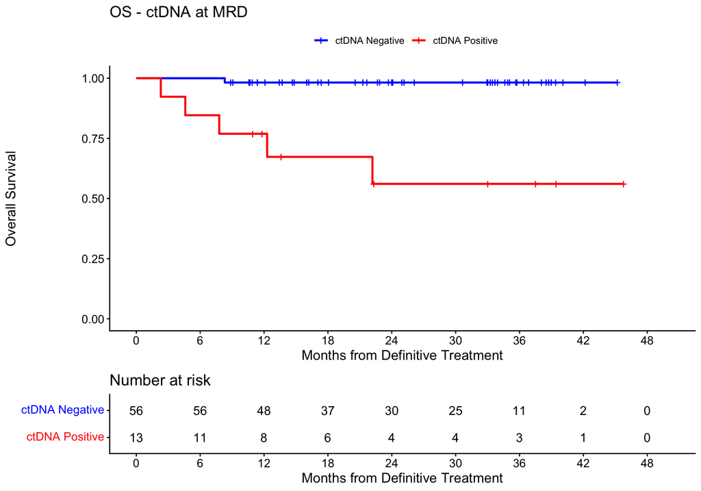

```r
surv_object <-Surv(time = circ_data$OS.months, event = circ_data$OS.Event)
KM_curve <- survfit(surv_object ~ ctDNA.MRD, data = circ_data,conf.int=0.95,conf.type="log-log")
ggsurvplot(KM_curve, data = circ_data, pval = FALSE, conf.int = FALSE, risk.table = TRUE, break.time.by=6, palette=c("blue","red"), title="OS - ctDNA at MRD", ylab= "Overall Survival", xlab="Months from Definitive Treatment", legend.labs=c("ctDNA Negative", "ctDNA Positive"), legend.title="")
```

```r
summary(KM_curve, times= c(12, 24, 36))
```

```
## Call: survfit(formula = surv_object ~ ctDNA.MRD, data = circ_data,
##     conf.int = 0.95, conf.type = "log-log")
##
##                 ctDNA.MRD=NEGATIVE
##  time n.risk n.event survival std.err lower 95% CI upper 95% CI
##    12     48       1    0.982  0.0177         0.88        0.997
##    24     30       0    0.982  0.0177         0.88        0.997
##    36     11       0    0.982  0.0177         0.88        0.997
##
##                 ctDNA.MRD=POSITIVE
##  time n.risk n.event survival std.err lower 95% CI upper 95% CI
##    12      8       3    0.769   0.117        0.442        0.919
##    24      4       2    0.561   0.153        0.233        0.795
##    36      3       0    0.561   0.153        0.233        0.795
```

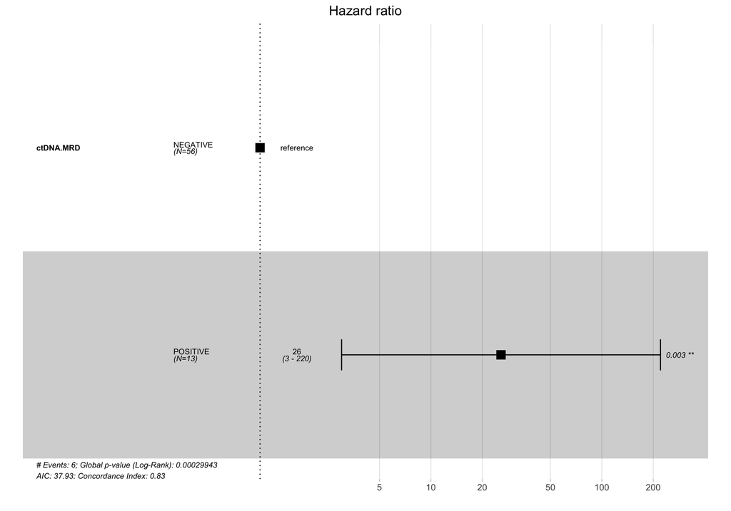

```r
circ_data$ctDNA.MRD <- factor(circ_data$ctDNA.MRD, levels=c("NEGATIVE","POSITIVE"))
cox_fit <- coxph(surv_object ~ ctDNA.MRD, data=circ_data)
ggforest(cox_fit,data = circ_data)
```

```r
summary(cox_fit)
```

```
## Call:
## coxph(formula = surv_object ~ ctDNA.MRD, data = circ_data)
##
##   n= 69, number of events= 6
##
##                     coef exp(coef) se(coef)     z Pr(>|z|)
## ctDNA.MRDPOSITIVE  3.247    25.718    1.096 2.962  0.00306 **
## ---
## Signif. codes:  0 '***' 0.001 '**' 0.01 '*' 0.05 '.' 0.1 ' ' 1
##
##                   exp(coef) exp(-coef) lower .95 upper .95
## ctDNA.MRDPOSITIVE     25.72    0.03888         3     220.5
##
## Concordance= 0.832  (se = 0.081 )
## Likelihood ratio test= 13.07  on 1 df,   p=3e-04
## Wald test            = 8.77  on 1 df,   p=0.003
## Score (logrank) test = 19.67  on 1 df,   p=9e-06
```

```r
cox_fit_summary <- summary(cox_fit)

#Extract values for HR, 95% CI, and p-value
HR <- cox_fit_summary$coefficients[2]
lower_CI <- cox_fit_summary$conf.int[3]
upper_CI <- cox_fit_summary$conf.int[4]
p_value <- cox_fit_summary$coefficients[5]
label_text <- paste0("HR = ", round(HR, 2), " (", round(lower_CI, 2), "-", round(upper_CI, 2), "); p = ", round(p_value, 3))
print(label_text)
```

```
## [1] "HR = 25.72 (3-220.48); p = 0.003"
```

```r
circ_data$ctDNA.MRD <- factor(circ_data$ctDNA.MRD, levels = c("NEGATIVE", "POSITIVE"), labels = c("Negative", "Positive"))
circ_data$OS.Event <- factor(circ_data$OS.Event, levels = c("FALSE", "TRUE"), labels = c("Alive", "Deceased"))
contingency_table <- table(circ_data$ctDNA.MRD, circ_data$OS.Event)
chi_square_test <- chisq.test(contingency_table)
print(chi_square_test)
```

```
##
##  Pearson's Chi-squared test with Yates' continuity correction
##
## data:  contingency_table
## X-squared = 13.554, df = 1, p-value = 0.0002318
```

```r
fisher_exact_test <- fisher.test(contingency_table)
print(fisher_exact_test)
```

```
##
##  Fisher's Exact Test for Count Data
##
## data:  contingency_table
## p-value = 0.0006155
## alternative hypothesis: true odds ratio is not equal to 1
## 95 percent confidence interval:
##     3.015475 1634.641331
## sample estimates:
## odds ratio
##   31.44433
```

```r
print(contingency_table)
```

```
##
##            Alive Deceased
##   Negative    55        1
##   Positive     8        5
```

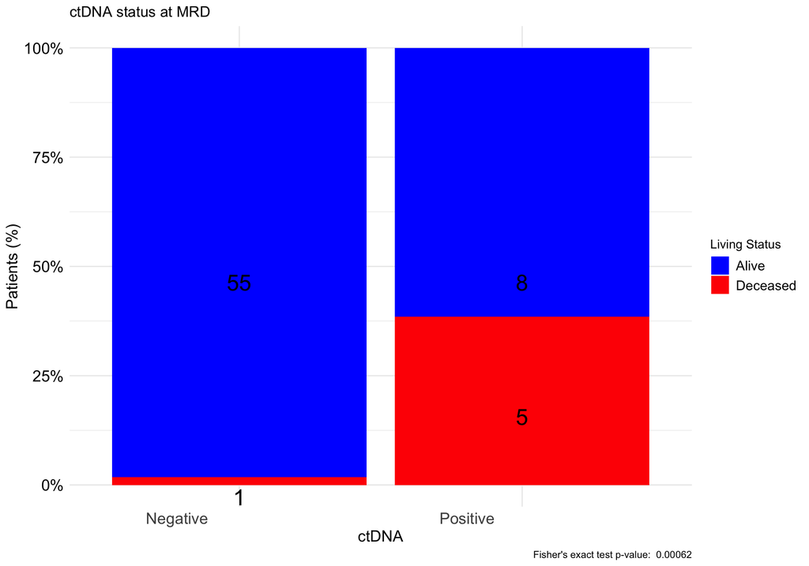

```r
table_df <- as.data.frame(contingency_table)
table_df$Total <- ave(table_df$Freq, table_df$Var1, FUN = sum)
table_df$Percentage <- table_df$Freq / table_df$Total
table_df$MiddlePercentage <- table_df$Percentage / 2
ggplot(table_df, aes(x = Var1, y = Percentage, fill = Var2)) +
  geom_bar(stat = "identity") +
  geom_text(aes(y = MiddlePercentage, label = Freq), position = "stack", color = "black", vjust = 1.5, size = 7) +
  theme_minimal() +
  labs(title = "ctDNA status at MRD",
       x = "ctDNA",
       y = "Patients (%)",
       fill = "Living Status",
       caption = paste("Fisher's exact test p-value: ", format.pval(fisher_exact_test$p.value))) +
  scale_y_continuous(labels = scales::percent_format()) +
  scale_fill_manual(values = c("Alive" = "blue", "Deceased" = "red")) + # define custom colors
  theme(axis.text.x = element_text(angle = 0, hjust = 1.5, size = 14), # increase x-axis text size
        axis.text.y = element_text(size = 14, color = "black"), # increase y-axis text size
        axis.title.x = element_text(size = 14, color = "black"), # increase x-axis label size
        axis.title.y = element_text(size = 14, color = "black"), # increase y-axis label size
        legend.text = element_text(size = 12, color = "black"))  # increase Progression label size
```

# 6. Supplementary Figure 1

Kaplan-Meier estimates of PFS stratified by ctDNA status in the MRD window among patients with HNSCC who did not receive any adjuvant therapy after surgery/definitive treatment

```r
rm(list=ls())
setwd("~/Downloads")
circ_data <- read.csv("CLIA HNSCC Peddada Clinical Data.csv")
circ_data <- circ_data[circ_data$ctDNA.available=="TRUE",]
circ_data <- circ_data[circ_data$ctDNA.MRD!="",]
excluded_ids <- c("UNM-007", "UNM-008", "UNM-023", "UNM-027", "UNM-029",
                  "UNM-030", "UNM-035", "UNM-045", "UNM-051", "UNM-059",
                  "UNM-075", "UNM-082", "UNM-032", "UNM-042", "UNM-043",
                  "UNM-048", "UNM-050", "UNM-070")
circ_data <- circ_data[!circ_data$PatientID %in% excluded_ids, ]

survfit(Surv(time = circ_data$PFS.months, event = circ_data$PFS.Event)~ctDNA.MRD, data = circ_data)
```

```
## Call: survfit(formula = Surv(time = circ_data$PFS.months, event = circ_data$PFS.Event) ~
##     ctDNA.MRD, data = circ_data)
##
##                     n events median 0.95LCL 0.95UCL
## ctDNA.MRD=NEGATIVE 44      7     NA   40.08      NA
## ctDNA.MRD=POSITIVE  7      6   11.3    3.12      NA
```

```r
event_summary <- circ_data %>%
  group_by(ctDNA.MRD) %>%
  summarise(
    Total = n(),
    Events = sum(PFS.Event),
    Fraction = Events / n(),
    Percentage = (Events / n()) * 100
  )
print(event_summary)
```

```
## # A tibble: 2 × 5
##   ctDNA.MRD Total Events Fraction Percentage
##   <chr>     <int>  <int>    <dbl>      <dbl>
## 1 NEGATIVE     44      7    0.159       15.9
## 2 POSITIVE      7      6    0.857       85.7
```

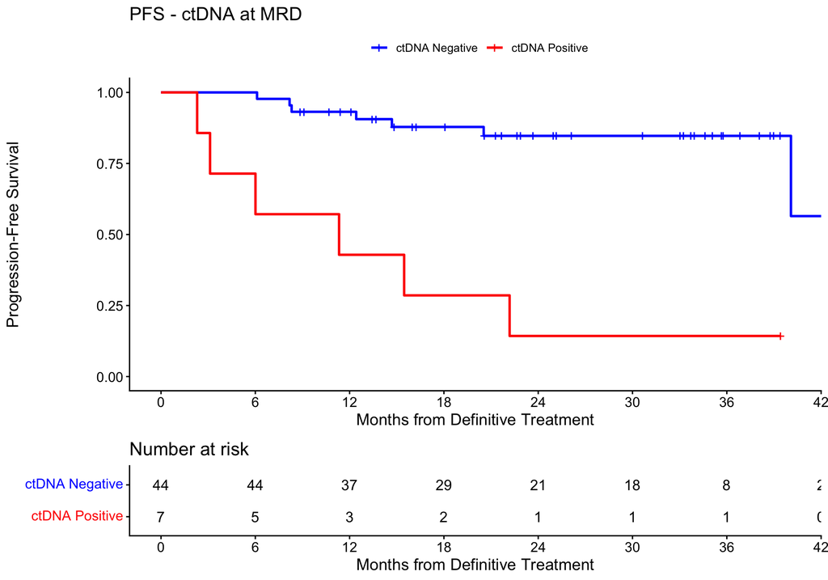

```r
surv_object <-Surv(time = circ_data$PFS.months, event = circ_data$PFS.Event)
KM_curve <- survfit(surv_object ~ ctDNA.MRD, data = circ_data,conf.int=0.95,conf.type="log-log")
ggsurvplot(KM_curve, data = circ_data, pval = FALSE, conf.int = FALSE, risk.table = TRUE, break.time.by=6, palette=c("blue","red"), title="PFS - ctDNA at MRD", ylab= "Progression-Free Survival", xlab="Months from Definitive Treatment", legend.labs=c("ctDNA Negative", "ctDNA Positive"), legend.title="")
```

```r
summary(KM_curve, times= c(0, 12, 24, 36))
```

```
## Call: survfit(formula = surv_object ~ ctDNA.MRD, data = circ_data,
##     conf.int = 0.95, conf.type = "log-log")
##
##                 ctDNA.MRD=NEGATIVE
##  time n.risk n.event survival std.err lower 95% CI upper 95% CI
##     0     44       0    1.000  0.0000        1.000        1.000
##    12     37       3    0.932  0.0380        0.803        0.977
##    24     21       3    0.847  0.0582        0.688        0.929
##    36      8       0    0.847  0.0582        0.688        0.929
##
##                 ctDNA.MRD=POSITIVE
##  time n.risk n.event survival std.err lower 95% CI upper 95% CI
##     0      7       0    1.000   0.000      1.00000        1.000
##    12      3       4    0.429   0.187      0.09775        0.734
##    24      1       2    0.143   0.132      0.00712        0.465
##    36      1       0    0.143   0.132      0.00712        0.465
```

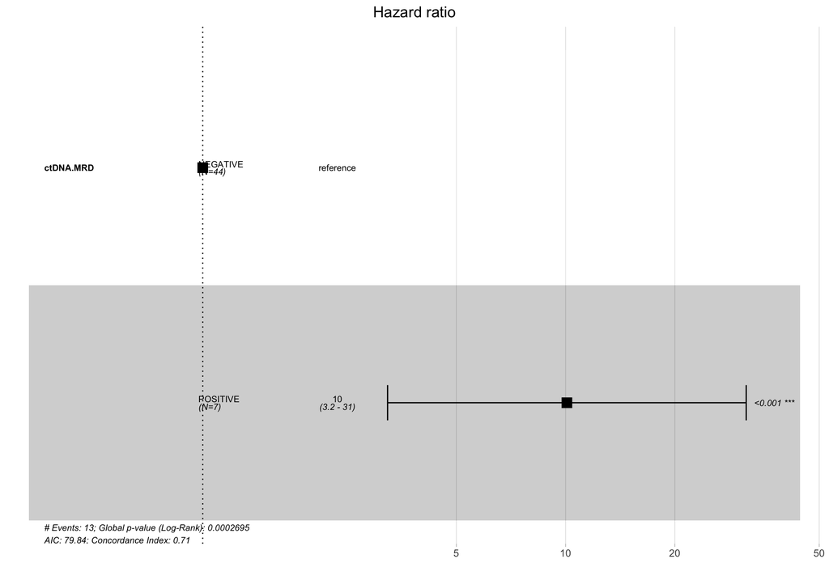

```r
circ_data$ctDNA.MRD <- factor(circ_data$ctDNA.MRD, levels=c("NEGATIVE","POSITIVE"))
cox_fit <- coxph(surv_object ~ ctDNA.MRD, data=circ_data)
ggforest(cox_fit,data = circ_data)
```

```r
summary(cox_fit)
```

```
## Call:
## coxph(formula = surv_object ~ ctDNA.MRD, data = circ_data)
##
##   n= 51, number of events= 13
##
##                      coef exp(coef) se(coef)     z Pr(>|z|)
## ctDNA.MRDPOSITIVE  2.3109   10.0834   0.5805 3.981 6.87e-05 ***
## ---
## Signif. codes:  0 '***' 0.001 '**' 0.01 '*' 0.05 '.' 0.1 ' ' 1
##
##                   exp(coef) exp(-coef) lower .95 upper .95
## ctDNA.MRDPOSITIVE     10.08    0.09917     3.232     31.46
##
## Concordance= 0.71  (se = 0.067 )
## Likelihood ratio test= 13.27  on 1 df,   p=3e-04
## Wald test            = 15.85  on 1 df,   p=7e-05
## Score (logrank) test = 24.07  on 1 df,   p=9e-07
```

```r
cox_fit_summary <- summary(cox_fit)

#Extract values for HR, 95% CI, and p-value
HR <- cox_fit_summary$coefficients[2]
lower_CI <- cox_fit_summary$conf.int[3]
upper_CI <- cox_fit_summary$conf.int[4]
p_value <- cox_fit_summary$coefficients[5]
label_text <- paste0("HR = ", round(HR, 2), " (", round(lower_CI, 2), "-", round(upper_CI, 2), "); p = ", round(p_value, 3))
print(label_text)
```

```
## [1] "HR = 10.08 (3.23-31.46); p = 0"
```

```r
circ_data$ctDNA.MRD <- factor(circ_data$ctDNA.MRD, levels = c("NEGATIVE", "POSITIVE"), labels = c("Negative", "Positive"))
circ_data$PFS.Event <- factor(circ_data$PFS.Event, levels = c("FALSE", "TRUE"), labels = c("No Progression", "Progression"))
contingency_table <- table(circ_data$ctDNA.MRD, circ_data$PFS.Event)
chi_square_test <- chisq.test(contingency_table)
print(chi_square_test)
```

```
##
##  Pearson's Chi-squared test with Yates' continuity correction
##
## data:  contingency_table
## X-squared = 12.037, df = 1, p-value = 0.0005216
```

```r
fisher_exact_test <- fisher.test(contingency_table)
print(fisher_exact_test)
```

```
##
##  Fisher's Exact Test for Count Data
##
## data:  contingency_table
## p-value = 0.0005781
## alternative hypothesis: true odds ratio is not equal to 1
## 95 percent confidence interval:
##     2.866206 1480.826861
## sample estimates:
## odds ratio
##   28.65583
```

```r
print(contingency_table)
```

```
##
##            No Progression Progression
##   Negative             37           7
##   Positive              1           6
```

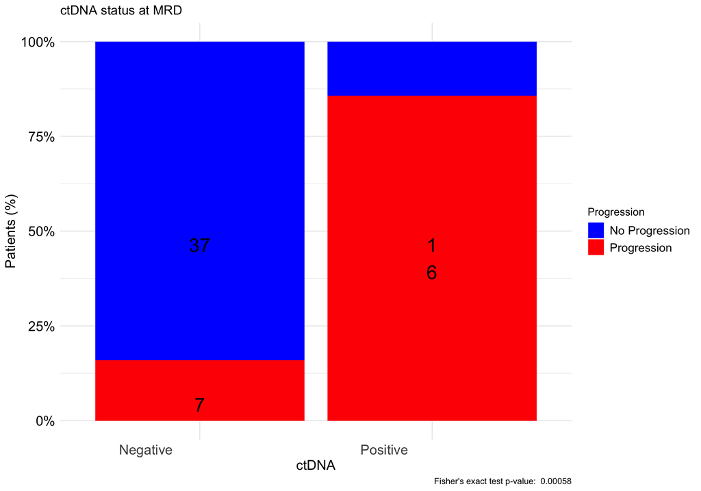

```r
table_df <- as.data.frame(contingency_table)
table_df$Total <- ave(table_df$Freq, table_df$Var1, FUN = sum)
table_df$Percentage <- table_df$Freq / table_df$Total
table_df$MiddlePercentage <- table_df$Percentage / 2
ggplot(table_df, aes(x = Var1, y = Percentage, fill = Var2)) +
  geom_bar(stat = "identity") +
  geom_text(aes(y = MiddlePercentage, label = Freq), position = "stack", color = "black", vjust = 1.5, size = 7) +
  theme_minimal() +
  labs(title = "ctDNA status at MRD",
       x = "ctDNA",
       y = "Patients (%)",
       fill = "Progression",
       caption = paste("Fisher's exact test p-value: ", format.pval(fisher_exact_test$p.value))) +
  scale_y_continuous(labels = scales::percent_format()) +
  scale_fill_manual(values = c("No Progression" = "blue", "Progression" = "red")) + # define custom colors
  theme(axis.text.x = element_text(angle = 0, hjust = 1.5, size = 14), # increase x-axis text size
        axis.text.y = element_text(size = 14, color = "black"), # increase y-axis text size
        axis.title.x = element_text(size = 14, color = "black"), # increase x-axis label size
        axis.title.y = element_text(size = 14, color = "black"), # increase y-axis label size
        legend.text = element_text(size = 12, color = "black"))  # increase Progression label size
```